# Indian Liver Disease Prediction

Bernardo Carraro Detanico

```r
knitr::opts_chunk$set(
    echo = TRUE,
    message = FALSE,
    warning = FALSE
)
```

### Introduction

The dataset was downloaded from the UCI ML Repository:Lichman, M. (2013). UCI Machine Learning Repository [http://archive.ics.uci.edu/ml]. Irvine, CA: University of California, School of Information and Computer Science.

This dataset contains 416 liver patient records and 167 non liver patient records. The data set was collected from north east of Andhra Pradesh, India.

**Objective:** Identify the best model(s) for liver disease prediction in an effort to help doctors diagnosis.

```r
library(dplyr)
library(ggplot2)
library(tidyverse)
library(gridExtra)
library(GGally)
library(caret)
library(MASS)
library(rpart)
library(corrplot)
library(rpart.plot)
library(randomForest)
library(NbClust)
library(stats)
library(Boruta)
library(e1071)
```

```r
setwd("~/R/Projects/1 - Liver")
df <- read_csv("indian_liver_patient.csv")
```

### Part 1 - Exploratory Data Analysis (EDA)

```r
summary(df)
```

```
##       Age           Gender          Total_Bilirubin  Direct_Bilirubin
##  Min.   : 4.00   Length:583         Min.   : 0.400   Min.   : 0.100
##  1st Qu.:33.00   Class :character   1st Qu.: 0.800   1st Qu.: 0.200
##  Median :45.00   Mode  :character   Median : 1.000   Median : 0.300
##  Mean   :44.75                      Mean   : 3.299   Mean   : 1.486
##  3rd Qu.:58.00                      3rd Qu.: 2.600   3rd Qu.: 1.300
##  Max.   :90.00                      Max.   :75.000   Max.   :19.700
##
##  Alkaline_Phosphotase Alamine_Aminotransferase Aspartate_Aminotransferase
##  Min.   :  63.0       Min.   :  10.00          Min.   :  10.0
##  1st Qu.: 175.5       1st Qu.:  23.00          1st Qu.:  25.0
##  Median : 208.0       Median :  35.00          Median :  42.0
##  Mean   : 290.6       Mean   :  80.71          Mean   : 109.9
##  3rd Qu.: 298.0       3rd Qu.:  60.50          3rd Qu.:  87.0
##  Max.   :2110.0       Max.   :2000.00          Max.   :4929.0
##
##  Total_Protiens     Albumin      Albumin_and_Globulin_Ratio
##  Min.   :2.700   Min.   :0.900   Min.   :0.3000
##  1st Qu.:5.800   1st Qu.:2.600   1st Qu.:0.7000
##  Median :6.600   Median :3.100   Median :0.9300
##  Mean   :6.483   Mean   :3.142   Mean   :0.9471
##  3rd Qu.:7.200   3rd Qu.:3.800   3rd Qu.:1.1000
##  Max.   :9.600   Max.   :5.500   Max.   :2.8000
##                                  NA's   :4
##     Dataset
##  Min.   :1.000
##  1st Qu.:1.000
##  Median :1.000
##  Mean   :1.286
##  3rd Qu.:2.000
##  Max.   :2.000
##
```

```r
df <- df %>%
  filter(!is.na(Albumin_and_Globulin_Ratio)) # The Albumin_and_Globulin_Ratio had 4 NA entry, so I remove them.

# unique(df$Gender) # Verify the unique values in Gender variable
df$Gender <- as.factor(df$Gender) # Transform chr to factor
df$Dataset <- as.factor(df$Dataset) # Transform chr to factor
levels(df$Dataset) <- c("liver_disease", "no_liver_disease") # Rename
df.o <- df # Original Dataframe
```

We created the AST_ALT_ratio variable, since the ratio of AST (Aspartate_Aminotransferase) to ALT (Alamine_Aminotransferase) is used as a clinical parameter for liver disease condition.

```r
df.o <- df.o %>% # create a new variable (AST/ALT ratio)
  mutate(AST_ALT_ratio = Aspartate_Aminotransferase/Alamine_Aminotransferase)
df.o <- df.o[,c(1:10, 12, 11)] #change columns order
```

The distribution of the original data:

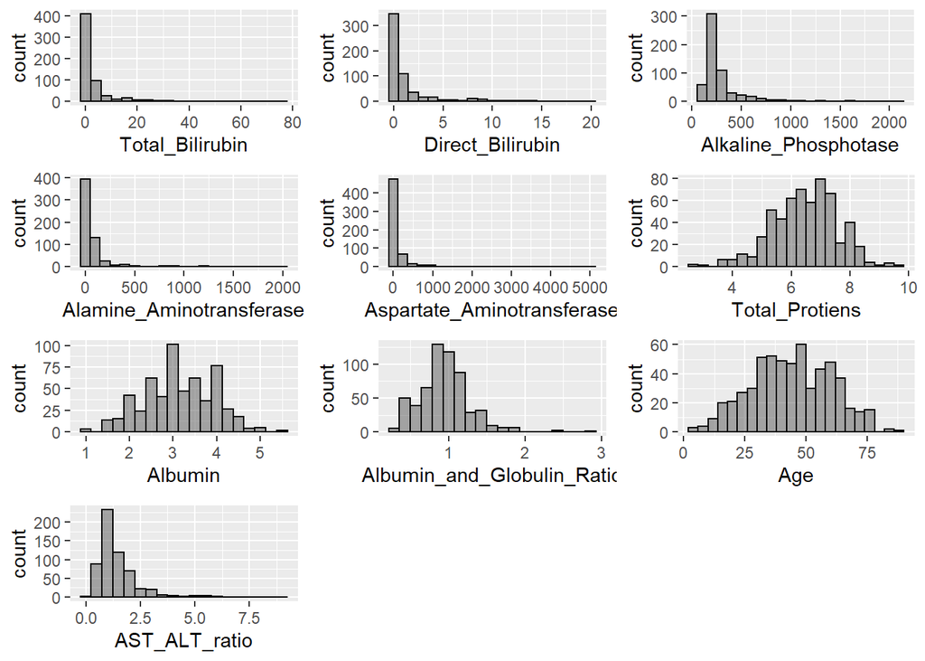

```r
ph1 <- ggplot(df.o, aes(x=Total_Bilirubin)) +
    geom_histogram(binwidth=4, colour="black", alpha=.5)

ph2 <- ggplot(df.o, aes(x=Direct_Bilirubin)) +
    geom_histogram(binwidth=1, colour="black", alpha=.5)

ph3 <- ggplot(df.o, aes(x=Alkaline_Phosphotase)) +
    geom_histogram(binwidth=100, colour="black", alpha=.5)

ph4 <- ggplot(df.o, aes(x=Alamine_Aminotransferase)) +
    geom_histogram(binwidth=100, colour="black", alpha=.5)

ph5 <- ggplot(df.o, aes(x=Aspartate_Aminotransferase)) +
    geom_histogram(binwidth=240, colour="black", alpha=.5)

ph6 <- ggplot(df.o, aes(x=Total_Protiens)) +
    geom_histogram(binwidth=1/3, colour="black", alpha=.5)

ph7 <- ggplot(df.o, aes(x=Albumin)) +
    geom_histogram(binwidth=1/4, colour="black", alpha=.5)

ph8 <- ggplot(df.o, aes(x=Albumin_and_Globulin_Ratio)) +
    geom_histogram(binwidth=1/7, colour="black", alpha=.5)

ph9 <- ggplot(df.o, aes(x=Age)) +
    geom_histogram(binwidth=4, colour="black", alpha=.5)

ph10 <- ggplot(df.o, aes(x=AST_ALT_ratio)) +
    geom_histogram(binwidth=1/2, colour="black", alpha=.5)

grid.arrange(ph1, ph2, ph3, ph4, ph5, ph6, ph7, ph8, ph9, ph10, ncol=3)
```

The box plots of the original data:

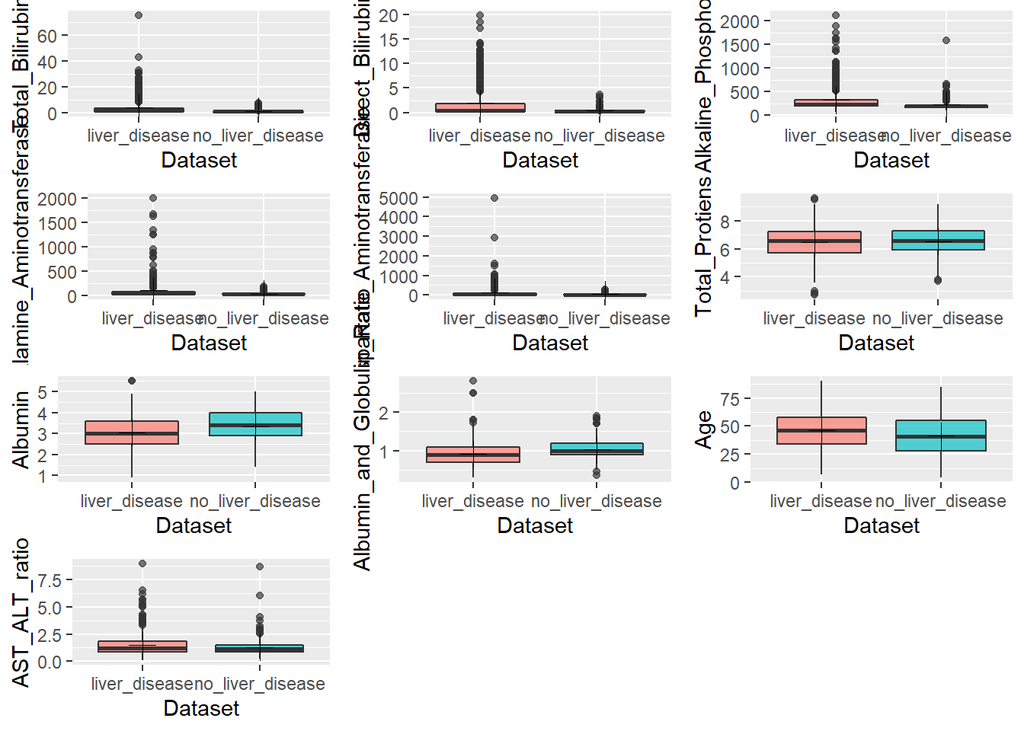

```r
pb1 <- ggplot(df.o, aes(Dataset, Total_Bilirubin)) + geom_boxplot(aes(fill = Dataset), alpha = 2/3) + stat_summary(fun.y=mean, geom="point", shape=3, size=4) + theme(legend.position = "none")

pb2 <- ggplot(df.o, aes(Dataset, Direct_Bilirubin)) + geom_boxplot(aes(fill = Dataset), alpha = 2/3) + stat_summary(fun.y=mean, geom="point", shape=3, size=4) + theme(legend.position = "none")

pb3 <- ggplot(df.o, aes(Dataset, Alkaline_Phosphotase)) + geom_boxplot(aes(fill = Dataset), alpha = 2/3) + stat_summary(fun.y=mean, geom="point", shape=3, size=4) + theme(legend.position = "none")

pb4 <- ggplot(df.o, aes(Dataset, Alamine_Aminotransferase)) + geom_boxplot(aes(fill = Dataset), alpha = 2/3) + stat_summary(fun.y=mean, geom="point", shape=3, size=4) + theme(legend.position = "none")

pb5 <- ggplot(df.o, aes(Dataset, Aspartate_Aminotransferase)) + geom_boxplot(aes(fill = Dataset), alpha = 2/3) + stat_summary(fun.y=mean, geom="point", shape=3, size=4) + theme(legend.position = "none")

pb6 <- ggplot(df.o, aes(Dataset, Total_Protiens)) + geom_boxplot(aes(fill = Dataset), alpha = 2/3) + stat_summary(fun.y=mean, geom="point", shape=3, size=4) + theme(legend.position = "none")

pb7 <- ggplot(df.o, aes(Dataset, Albumin)) + geom_boxplot(aes(fill = Dataset), alpha = 2/3) + stat_summary(fun.y=mean, geom="point", shape=3, size=4) + theme(legend.position = "none")

pb8 <- ggplot(df.o, aes(Dataset, Albumin_and_Globulin_Ratio)) + geom_boxplot(aes(fill = Dataset), alpha = 2/3) + stat_summary(fun.y=mean, geom="point", shape=3, size=4) + theme(legend.position = "none")

pb9 <- ggplot(df.o, aes(Dataset, Age)) + geom_boxplot(aes(fill = Dataset), alpha = 2/3) + stat_summary(fun.y=mean, geom="point", shape=3, size=4) + theme(legend.position = "none")

pb10 <- ggplot(df.o, aes(Dataset, AST_ALT_ratio)) + geom_boxplot(aes(fill = Dataset), alpha = 2/3) + stat_summary(fun.y=mean, geom="point", shape=3, size=4) + theme(legend.position = "none")

grid.arrange(pb1, pb2, pb3, pb4, pb5, pb6, pb7, pb8, pb9, pb10, ncol=3)
```

Some variables have a skewed distribution (some extreme values), so that we applied the log transformation in order to improve the data distribution.

```r
df.o.log <- df.o
df.o.log[,c("Total_Bilirubin", "Direct_Bilirubin", "Alkaline_Phosphotase", "Alamine_Aminotransferase", "Aspartate_Aminotransferase", "Albumin_and_Globulin_Ratio", "AST_ALT_ratio")] <- lapply(df.o.log[,c("Total_Bilirubin", "Direct_Bilirubin", "Alkaline_Phosphotase", "Alamine_Aminotransferase", "Aspartate_Aminotransferase", "Albumin_and_Globulin_Ratio", "AST_ALT_ratio")], function(x) (log(x+1)))
```

The distribution of the data pos-log transformation:

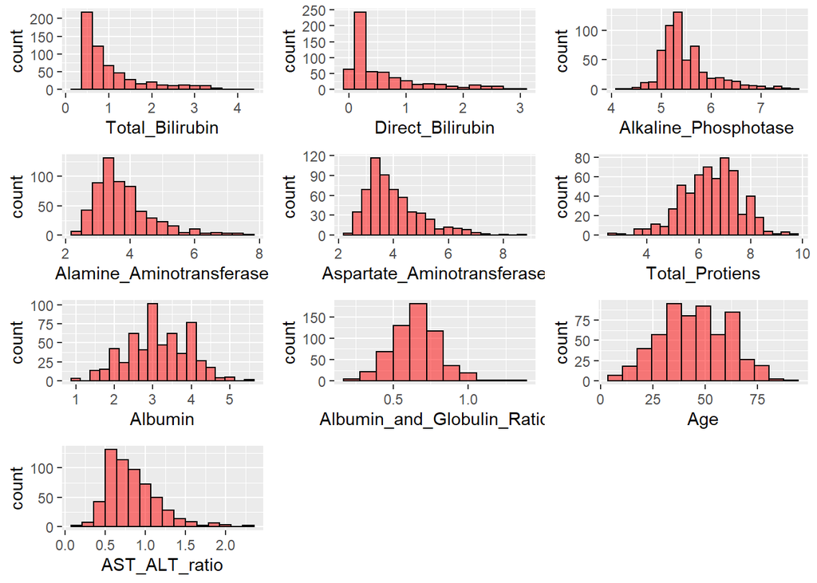

```r
phh1 <- ggplot(df.o.log, aes(x=Total_Bilirubin)) +
    geom_histogram(binwidth=1/4, fill="red", colour="black", alpha=.5)

phh2 <- ggplot(df.o.log, aes(x=Direct_Bilirubin)) +
    geom_histogram(binwidth=1/5, fill="red", colour="black", alpha=.5)

phh3 <- ggplot(df.o.log, aes(x=Alkaline_Phosphotase)) +
    geom_histogram(binwidth=1/6, fill="red", colour="black", alpha=.5)

phh4 <- ggplot(df.o.log, aes(x=Alamine_Aminotransferase)) +
    geom_histogram(binwidth=1/3, fill="red", colour="black", alpha=.5)

phh5 <- ggplot(df.o.log, aes(x=Aspartate_Aminotransferase)) +
    geom_histogram(binwidth=1/3, fill="red", colour="black", alpha=.5)

phh6 <- ggplot(df.o.log, aes(x=Total_Protiens)) +
    geom_histogram(binwidth=1/3, fill="red", colour="black", alpha=.5)

phh7 <- ggplot(df.o.log, aes(x=Albumin)) +
    geom_histogram(binwidth=1/4, fill="red", colour="black", alpha=.5)

phh8 <- ggplot(df.o.log, aes(x=Albumin_and_Globulin_Ratio)) +
    geom_histogram(binwidth=1/9, fill="red", colour="black", alpha=.5)

phh9 <- ggplot(df.o.log, aes(x=Age)) +
    geom_histogram(binwidth=7, fill="red", colour="black", alpha=.5)

phh10 <- ggplot(df.o.log, aes(x=AST_ALT_ratio)) +
    geom_histogram(binwidth=1/7, fill="red", colour="black", alpha=.5)

grid.arrange(phh1, phh2, phh3, phh4, phh5, phh6, phh7, phh8, phh9, phh10, ncol=3)
```

Alternatively, we decided to perform another transformation in order to tackle with extreme values, which could bias the statistic inferences and the predict models. For this, we used the boxplot.stats function and the rule that a data point is an outlier/extreme value if it is more than 1.5 * IQR (interquartile range) above the third quartile or below the first quartile.

```r
out1 <- sort.int(boxplot.stats(df.o$Total_Bilirubin)$out)
out2 <- sort.int(boxplot.stats(df.o$Direct_Bilirubin)$out)
out3 <- sort.int(boxplot.stats(df.o$Alkaline_Phosphotase)$out)
out4 <- sort.int(boxplot.stats(df.o$Alamine_Aminotransferase)$out)
out5 <- sort.int(boxplot.stats(df.o$Aspartate_Aminotransferase)$out)
out6 <- sort.int(boxplot.stats(df.o$Total_Protiens)$out)
out7 <- sort.int(boxplot.stats(df.o$Albumin)$out)
out8 <- sort.int(boxplot.stats(df.o$Albumin_and_Globulin_Ratio)$out)
out9 <- sort.int(boxplot.stats(df.o$Age)$out)
out10 <- sort.int(boxplot.stats(df.o$AST_ALT_ratio)$out)

df.o.wo <- df.o %>%
    mutate(Total_Bilirubin = replace(Total_Bilirubin, Total_Bilirubin >= 5.5, 5.3),
          Direct_Bilirubin = replace(Direct_Bilirubin, Direct_Bilirubin >= 3, 2.8),
          Alkaline_Phosphotase = replace(Alkaline_Phosphotase, Alkaline_Phosphotase >= 482, 480),
          Alamine_Aminotransferase = replace(Alamine_Aminotransferase, Alamine_Aminotransferase >= 119, 118),
          Aspartate_Aminotransferase = replace(Aspartate_Aminotransferase, Aspartate_Aminotransferase >= 181, 180),
          Total_Protiens = replace(Total_Protiens, Total_Protiens >= 9.5, 9.2),
          Total_Protiens = replace(Total_Protiens, Total_Protiens <= 3.6, 3.7),
          Albumin_and_Globulin_Ratio = replace(Albumin_and_Globulin_Ratio, Albumin_and_Globulin_Ratio >= 1.72, 1.7),
          AST_ALT_ratio = replace(AST_ALT_ratio, AST_ALT_ratio >= 3.1, 3))
```

The box plots of the data after dealing with the extreme values:

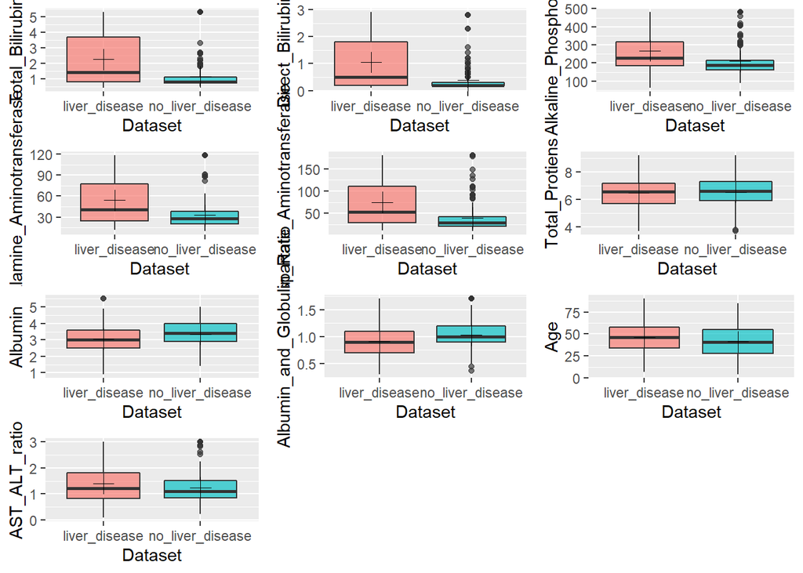

```r
pb1 <- ggplot(df.o.wo, aes(Dataset, Total_Bilirubin)) + geom_boxplot(aes(fill = Dataset), alpha = 2/3) + stat_summary(fun.y=mean, geom="point", shape=3, size=4) + theme(legend.position = "none")

pb2 <- ggplot(df.o.wo, aes(Dataset, Direct_Bilirubin)) + geom_boxplot(aes(fill = Dataset), alpha = 2/3) + stat_summary(fun.y=mean, geom="point", shape=3, size=4) + theme(legend.position = "none")

pb3 <- ggplot(df.o.wo, aes(Dataset, Alkaline_Phosphotase)) + geom_boxplot(aes(fill = Dataset), alpha = 2/3) + stat_summary(fun.y=mean, geom="point", shape=3, size=4) + theme(legend.position = "none")

pb4 <- ggplot(df.o.wo, aes(Dataset, Alamine_Aminotransferase)) + geom_boxplot(aes(fill = Dataset), alpha = 2/3) + stat_summary(fun.y=mean, geom="point", shape=3, size=4) + theme(legend.position = "none")

pb5 <- ggplot(df.o.wo, aes(Dataset, Aspartate_Aminotransferase)) + geom_boxplot(aes(fill = Dataset), alpha = 2/3) + stat_summary(fun.y=mean, geom="point", shape=3, size=4) + theme(legend.position = "none")

pb6 <- ggplot(df.o.wo, aes(Dataset, Total_Protiens)) + geom_boxplot(aes(fill = Dataset), alpha = 2/3) + stat_summary(fun.y=mean, geom="point", shape=3, size=4) + theme(legend.position = "none")

pb7 <- ggplot(df.o.wo, aes(Dataset, Albumin)) + geom_boxplot(aes(fill = Dataset), alpha = 2/3) + stat_summary(fun.y=mean, geom="point", shape=3, size=4) + theme(legend.position = "none")

pb8 <- ggplot(df.o.wo, aes(Dataset, Albumin_and_Globulin_Ratio)) + geom_boxplot(aes(fill = Dataset), alpha = 2/3) + stat_summary(fun.y=mean, geom="point", shape=3, size=4) + theme(legend.position = "none")

pb9 <- ggplot(df.o.wo, aes(Dataset, Age)) + geom_boxplot(aes(fill = Dataset), alpha = 2/3) + stat_summary(fun.y=mean, geom="point", shape=3, size=4) + theme(legend.position = "none")

pb10 <- ggplot(df.o.wo, aes(Dataset, AST_ALT_ratio)) + geom_boxplot(aes(fill = Dataset), alpha = 2/3) + stat_summary(fun.y=mean, geom="point", shape=3, size=4) + theme(legend.position = "none")

grid.arrange(pb1, pb2, pb3, pb4, pb5, pb6, pb7, pb8, pb9, pb10, ncol=3)
```

Additionally, we decided to perform the categorization of each column through the clustering approach in order to improve the statistic inferences and the predict models.

For this cluster analysis, we used the NbClust R package, which provides 30 indices for determining the best number of clusters with the Euclidean distance. The method of data clustering was hierarchical clustering with average linkage.

```r
df.cat <- df.o.wo

d3 <- dist(df.cat[, 3])
d4 <- dist(df.cat[, 4])
d5 <- dist(df.cat[, 5])
d6 <- dist(df.cat[, 6])
d7 <- dist(df.cat[, 7])
d8 <- dist(df.cat[, 8])
d9 <- dist(df.cat[, 9])
d10 <- dist(df.cat[, 10])
d11 <- dist(df.cat[, 11])

nc3 <- NbClust(scale(df.cat[, 3]), distance="euclidean", min.nc=2, max.nc=15, method="average") #5
```

```
## [1] "Frey index : No clustering structure in this data set"
```

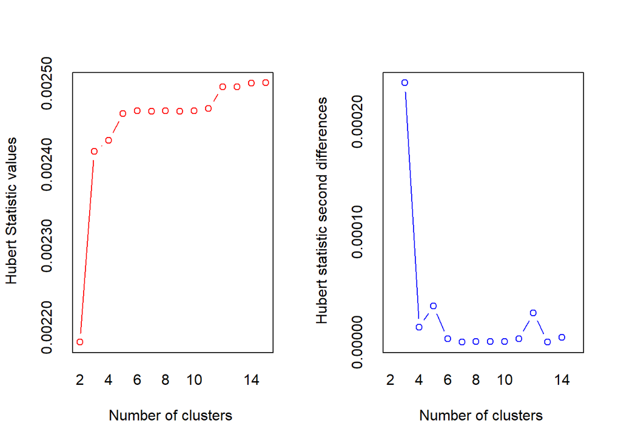

```
## *** : The Hubert index is a graphical method of determining the number of clusters.
##                 In the plot of Hubert index, we seek a significant knee that corresponds to a
##                 significant increase of the value of the measure i.e the significant peak in Hubert
##                 index second differences plot.
##
```

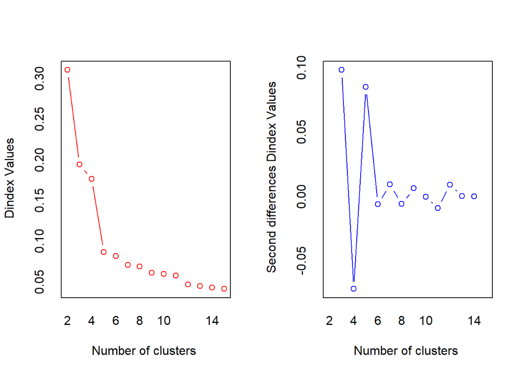

```
## *** : The D index is a graphical method of determining the number of clusters.
##                 In the plot of D index, we seek a significant knee (the significant peak in Dindex
##                 second differences plot) that corresponds to a significant increase of the value of
##                 the measure.
##
## * Among all indices:
## * 1 proposed 2 as the best number of clusters
## * 4 proposed 5 as the best number of clusters
## * 1 proposed 12 as the best number of clusters
##
##                    ***** Conclusion *****
##
## * According to the majority rule, the best number of clusters is  5
##
##
```

```r
nc4 <- NbClust(scale(df.cat[, 4]), distance="euclidean", min.nc=2, max.nc=15, method="average") #5
```

```
## [1] "Frey index : No clustering structure in this data set"
```

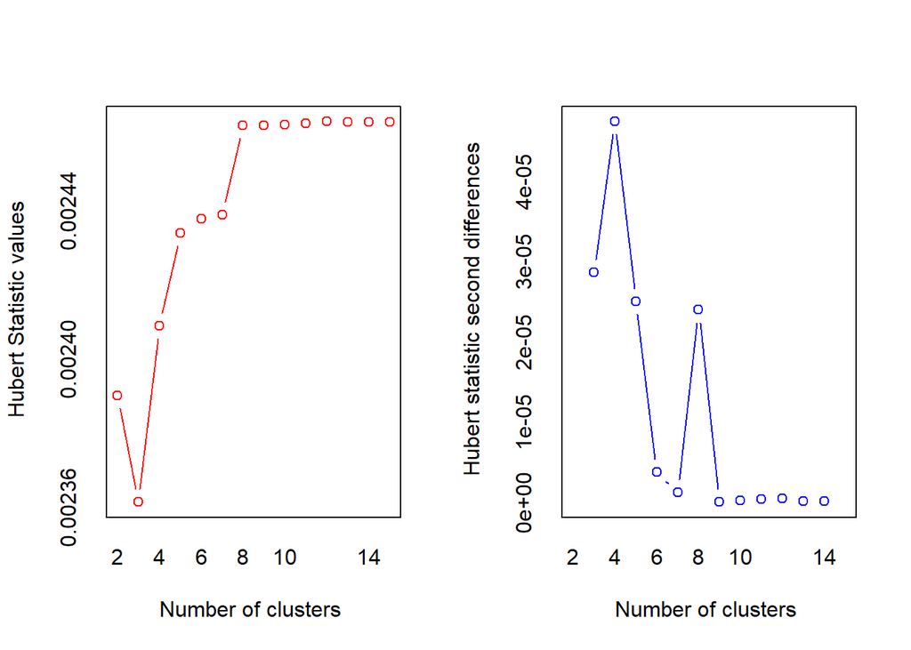

```
## *** : The Hubert index is a graphical method of determining the number of clusters.
##                 In the plot of Hubert index, we seek a significant knee that corresponds to a
##                 significant increase of the value of the measure i.e the significant peak in Hubert
##                 index second differences plot.
##
```

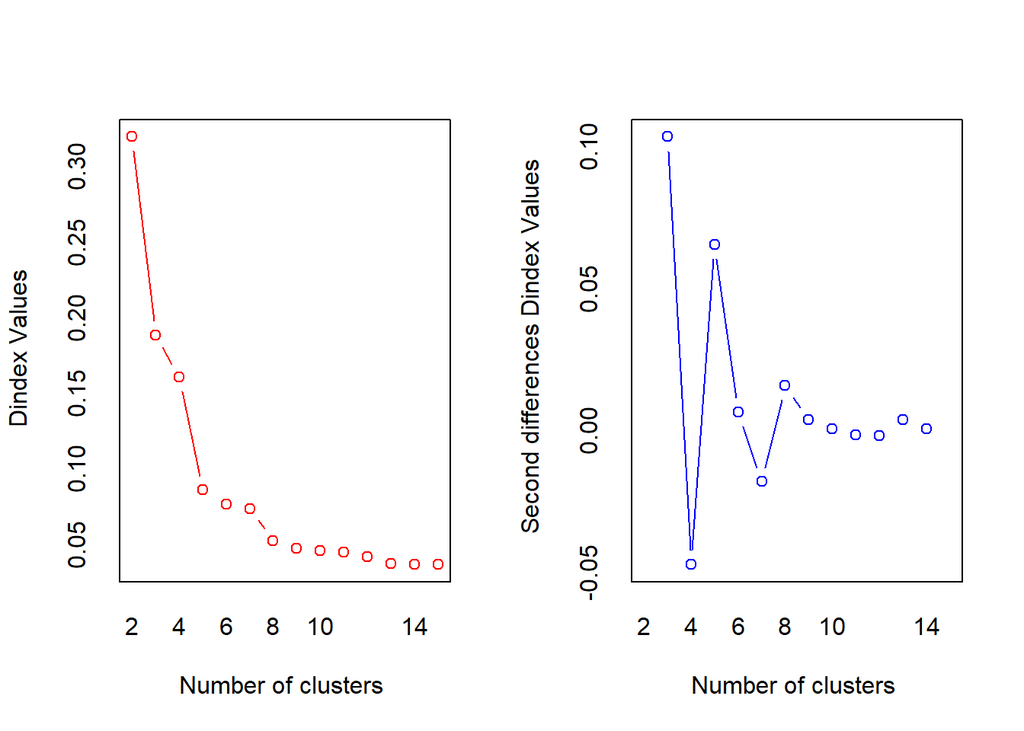

```
## *** : The D index is a graphical method of determining the number of clusters.
##                 In the plot of D index, we seek a significant knee (the significant peak in Dindex
##                 second differences plot) that corresponds to a significant increase of the value of
##                 the measure.
##
## * Among all indices:
## * 3 proposed 5 as the best number of clusters
## * 1 proposed 8 as the best number of clusters
## * 1 proposed 9 as the best number of clusters
## * 1 proposed 15 as the best number of clusters
##
##                    ***** Conclusion *****
##
## * According to the majority rule, the best number of clusters is  5
##
##
```

```r
nc5 <- NbClust(scale(df.cat[, 5]), distance="euclidean", min.nc=2, max.nc=15, method="average") #8
```

```
## [1] "Frey index : No clustering structure in this data set"
```

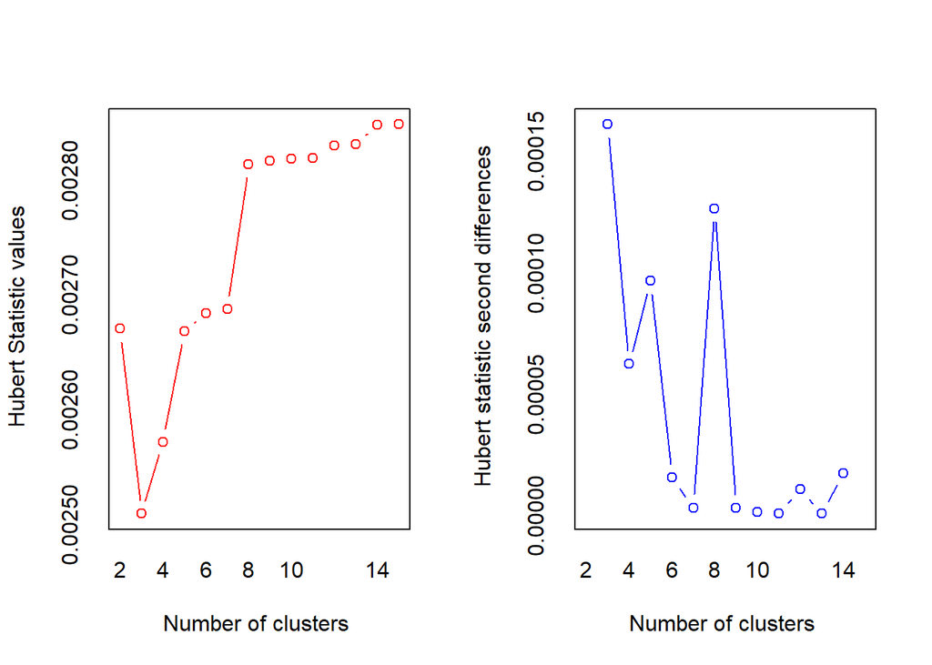

```
## *** : The Hubert index is a graphical method of determining the number of clusters.
##                 In the plot of Hubert index, we seek a significant knee that corresponds to a
##                 significant increase of the value of the measure i.e the significant peak in Hubert
##                 index second differences plot.
##
```

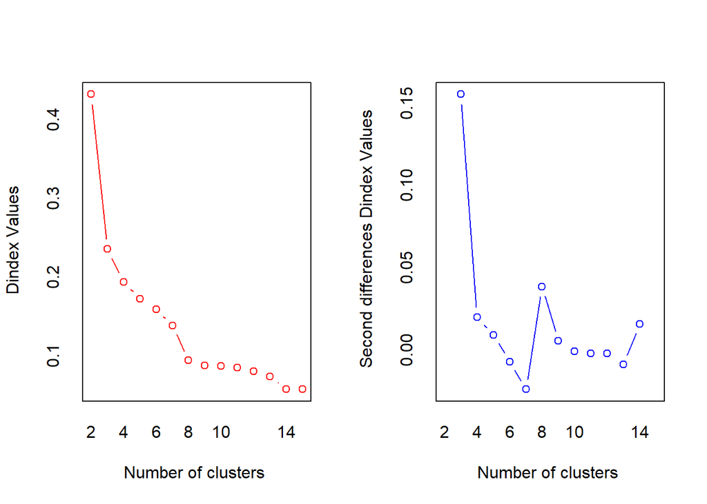

```
## *** : The D index is a graphical method of determining the number of clusters.
##                 In the plot of D index, we seek a significant knee (the significant peak in Dindex
##                 second differences plot) that corresponds to a significant increase of the value of
##                 the measure.
##
## * Among all indices:
## * 2 proposed 3 as the best number of clusters
## * 3 proposed 8 as the best number of clusters
## * 1 proposed 14 as the best number of clusters
##
##                    ***** Conclusion *****
##
## * According to the majority rule, the best number of clusters is  8
##
##
```

```r
nc6 <- NbClust(scale(df.cat[, 6]), distance="euclidean", min.nc=2, max.nc=15, method="average") #8
```

```
## [1] "Frey index : No clustering structure in this data set"
```

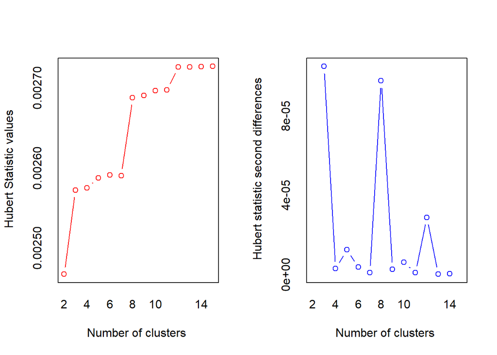

```
## *** : The Hubert index is a graphical method of determining the number of clusters.
##                 In the plot of Hubert index, we seek a significant knee that corresponds to a
##                 significant increase of the value of the measure i.e the significant peak in Hubert
##                 index second differences plot.
##
```

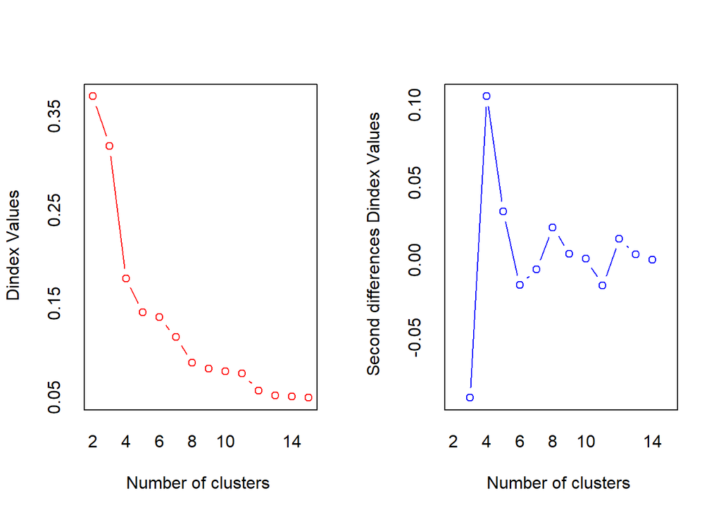

```
## *** : The D index is a graphical method of determining the number of clusters.
##                 In the plot of D index, we seek a significant knee (the significant peak in Dindex
##                 second differences plot) that corresponds to a significant increase of the value of
##                 the measure.
##
## * Among all indices:
## * 2 proposed 4 as the best number of clusters
## * 3 proposed 8 as the best number of clusters
## * 1 proposed 13 as the best number of clusters
##
##                    ***** Conclusion *****
##
## * According to the majority rule, the best number of clusters is  8
##
##
```

```r
nc7 <- NbClust(scale(df.cat[, 7]), distance="euclidean", min.nc=2, max.nc=15, method="average") #5
```

```
## [1] "Frey index : No clustering structure in this data set"
```

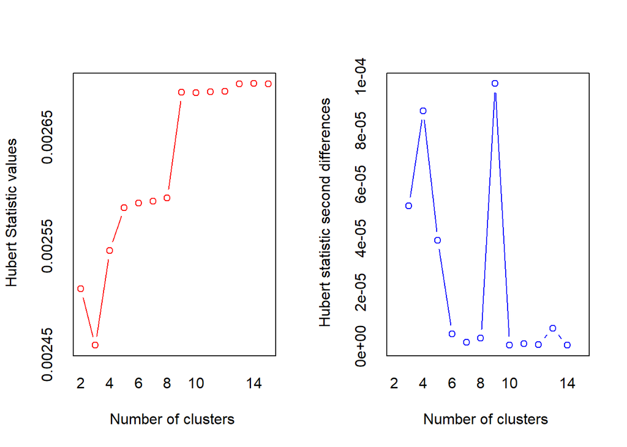

```
## *** : The Hubert index is a graphical method of determining the number of clusters.
##                 In the plot of Hubert index, we seek a significant knee that corresponds to a
##                 significant increase of the value of the measure i.e the significant peak in Hubert
##                 index second differences plot.
##
```

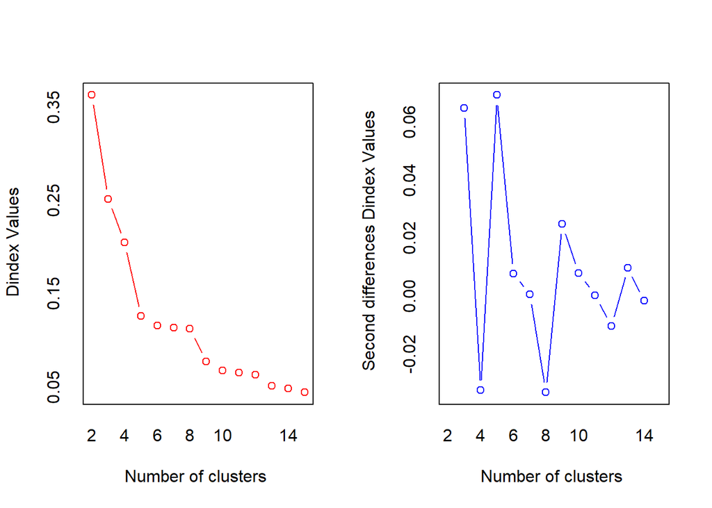

```
## *** : The D index is a graphical method of determining the number of clusters.
##                 In the plot of D index, we seek a significant knee (the significant peak in Dindex
##                 second differences plot) that corresponds to a significant increase of the value of
##                 the measure.
##
## * Among all indices:
## * 4 proposed 5 as the best number of clusters
## * 1 proposed 13 as the best number of clusters
## * 1 proposed 15 as the best number of clusters
##
##                    ***** Conclusion *****
##
## * According to the majority rule, the best number of clusters is  5
##
##
```

```r
nc8 <- NbClust(scale(df.cat[, 8]), distance="euclidean", min.nc=2, max.nc=15, method="average") #4
```

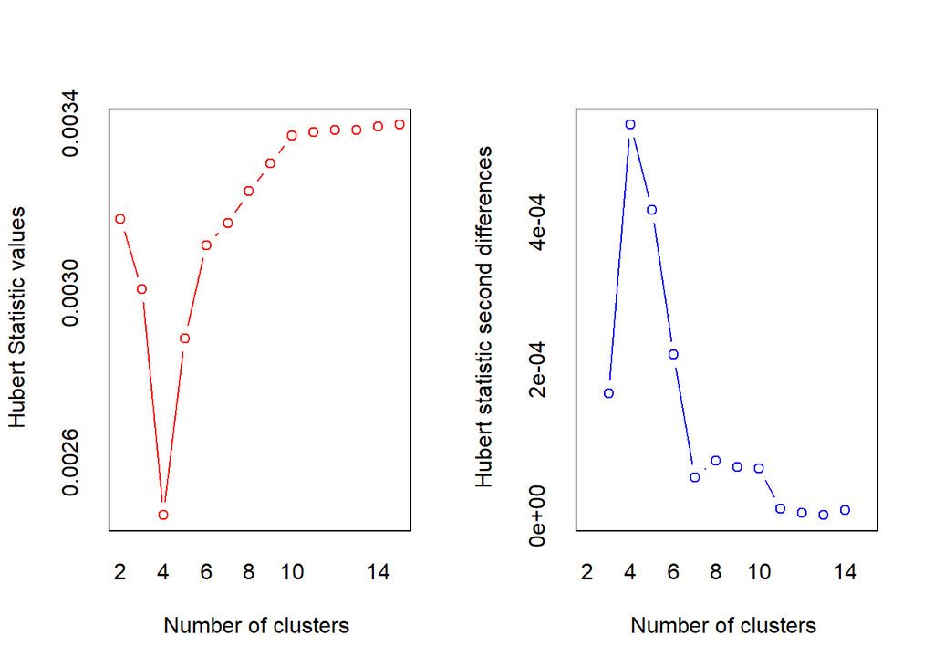

```
## *** : The Hubert index is a graphical method of determining the number of clusters.
##                 In the plot of Hubert index, we seek a significant knee that corresponds to a
##                 significant increase of the value of the measure i.e the significant peak in Hubert
##                 index second differences plot.
##
```

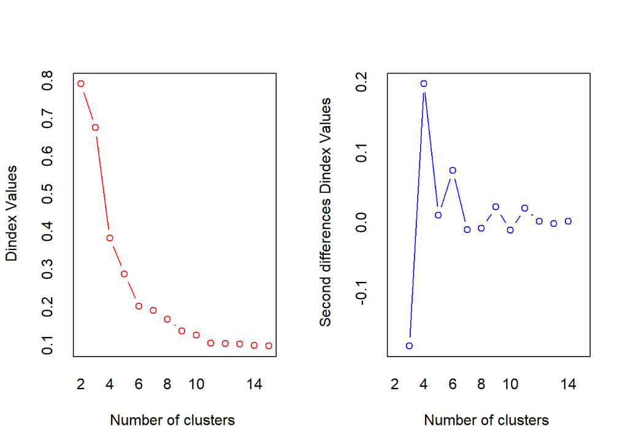

```
## *** : The D index is a graphical method of determining the number of clusters.
##                 In the plot of D index, we seek a significant knee (the significant peak in Dindex
##                 second differences plot) that corresponds to a significant increase of the value of
##                 the measure.
##
## * Among all indices:
## * 2 proposed 4 as the best number of clusters
## * 1 proposed 5 as the best number of clusters
## * 1 proposed 7 as the best number of clusters
## * 2 proposed 11 as the best number of clusters
##
##                    ***** Conclusion *****
##
## * According to the majority rule, the best number of clusters is  4
##
##
```

```r
nc9 <- NbClust(scale(df.cat[, 9]), distance="euclidean", min.nc=2, max.nc=15, method="average") #15
```

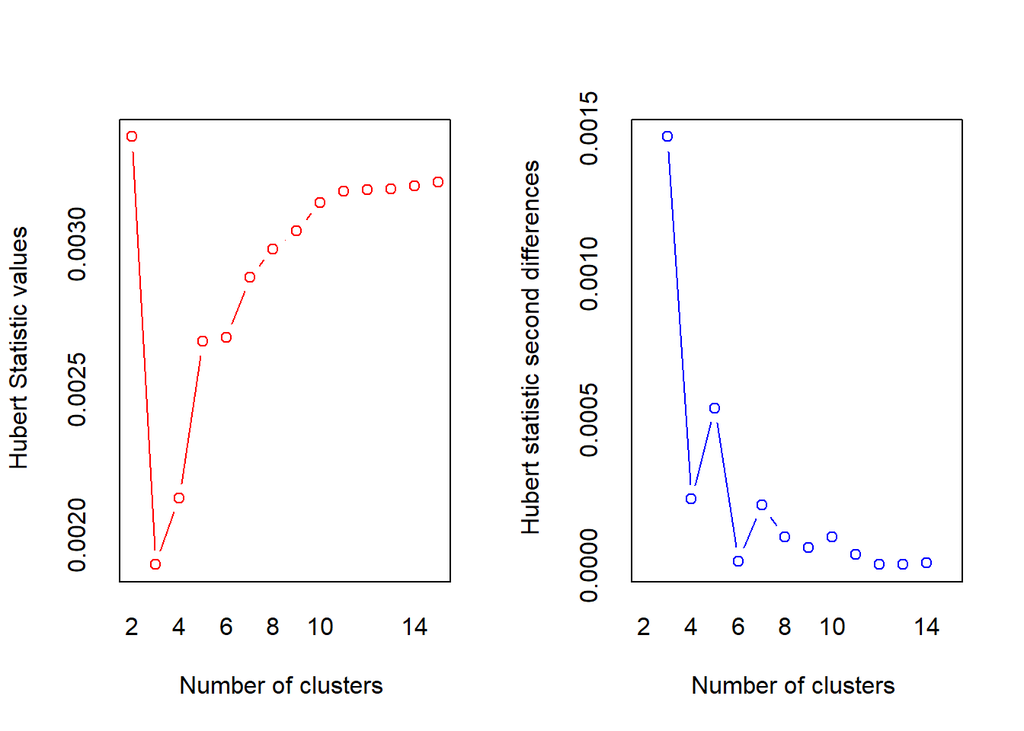

```
## *** : The Hubert index is a graphical method of determining the number of clusters.
##                 In the plot of Hubert index, we seek a significant knee that corresponds to a
##                 significant increase of the value of the measure i.e the significant peak in Hubert
##                 index second differences plot.
##
```

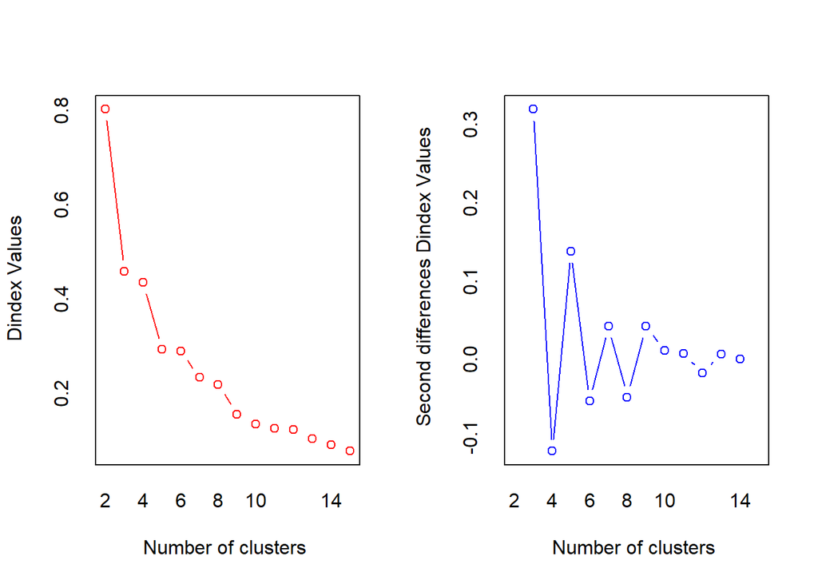

```
## *** : The D index is a graphical method of determining the number of clusters.
##                 In the plot of D index, we seek a significant knee (the significant peak in Dindex
##                 second differences plot) that corresponds to a significant increase of the value of
##                 the measure.
##
## * Among all indices:
## * 1 proposed 3 as the best number of clusters
## * 2 proposed 5 as the best number of clusters
## * 3 proposed 15 as the best number of clusters
##
##                    ***** Conclusion *****
##
## * According to the majority rule, the best number of clusters is  15
##
##
```

```r
nc10 <- NbClust(scale(df.cat[, 10]), distance="euclidean", min.nc=2, max.nc=15, method="average") #3
```

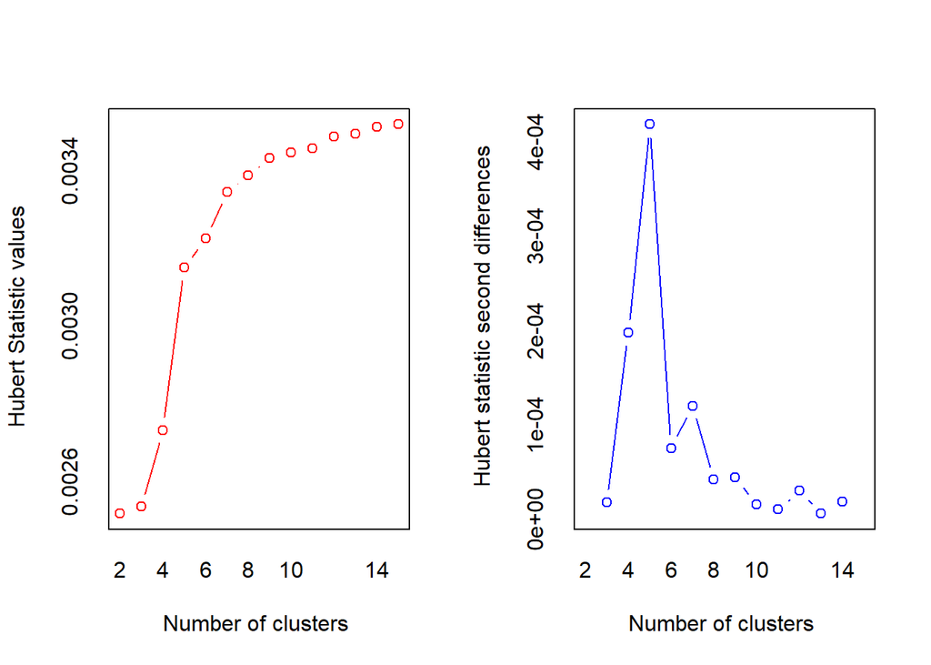

```
## *** : The Hubert index is a graphical method of determining the number of clusters.
##                 In the plot of Hubert index, we seek a significant knee that corresponds to a
##                 significant increase of the value of the measure i.e the significant peak in Hubert
##                 index second differences plot.
##
```

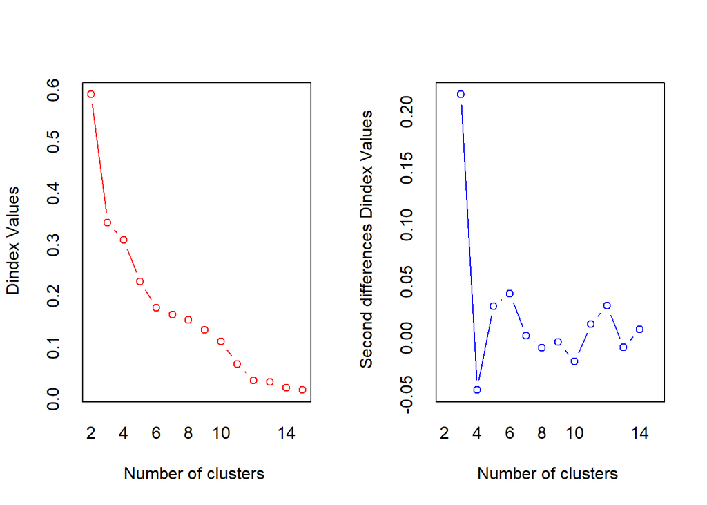

```
## *** : The D index is a graphical method of determining the number of clusters.
##                 In the plot of D index, we seek a significant knee (the significant peak in Dindex
##                 second differences plot) that corresponds to a significant increase of the value of
##                 the measure.
##
## * Among all indices:
## * 2 proposed 3 as the best number of clusters
## * 2 proposed 11 as the best number of clusters
## * 2 proposed 15 as the best number of clusters
##
##                    ***** Conclusion *****
##
## * According to the majority rule, the best number of clusters is  3
##
##
```

```r
nc11 <- NbClust(scale(df.cat[, 11]), distance="euclidean", min.nc=2, max.nc=15, method="average") #3
```

```
## [1] "Frey index : No clustering structure in this data set"
```

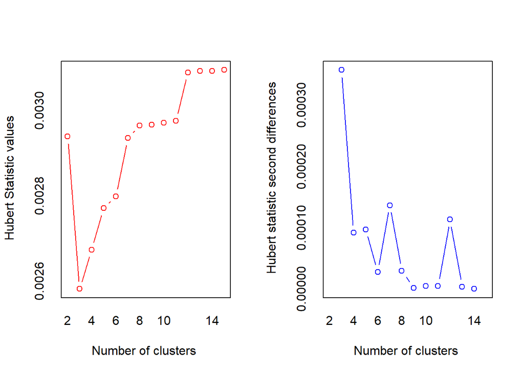

```
## *** : The Hubert index is a graphical method of determining the number of clusters.
##                 In the plot of Hubert index, we seek a significant knee that corresponds to a
##                 significant increase of the value of the measure i.e the significant peak in Hubert
##                 index second differences plot.
##
```

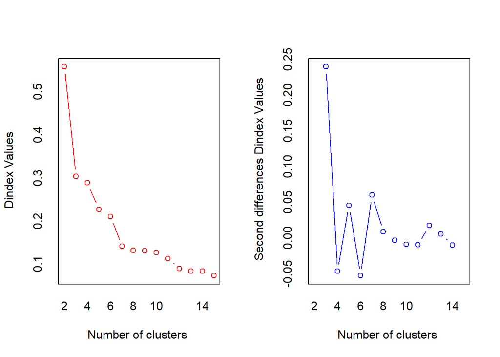

```
## *** : The D index is a graphical method of determining the number of clusters.
##                 In the plot of D index, we seek a significant knee (the significant peak in Dindex
##                 second differences plot) that corresponds to a significant increase of the value of
##                 the measure.
##
## * Among all indices:
## * 3 proposed 3 as the best number of clusters
## * 1 proposed 6 as the best number of clusters
## * 1 proposed 7 as the best number of clusters
## * 1 proposed 8 as the best number of clusters
##
##                    ***** Conclusion *****
##
## * According to the majority rule, the best number of clusters is  3
##
##
```

```r
fit3 <- hclust(d3, method="average")
fit4 <- hclust(d4, method="average")
fit5 <- hclust(d5, method="average")
fit6 <- hclust(d6, method="average")
fit7 <- hclust(d7, method="average")
fit8 <- hclust(d8, method="average")
fit9 <- hclust(d9, method="average")
fit10 <- hclust(d10, method="average")
fit11 <- hclust(d11, method="average")

c3 <- cutree(fit3, k=5)
c4 <- cutree(fit4, k=5)
c5 <- cutree(fit5, k=8)
c6 <- cutree(fit6, k=8)
c7 <- cutree(fit7, k=5)
c8 <- cutree(fit8, k=4)
c9 <- cutree(fit9, k=15)
c10 <- cutree(fit10, k=3)
c11 <- cutree(fit11, k=3)

df.catfinal <- cbind(df.cat, c3, c4, c5, c6, c7, c8, c9, c10, c11)
df.catfinal2 <- subset(df.catfinal, select = c("Age", "Gender", "Total_Bilirubin", "c3", "Direct_Bilirubin", "c4", "Alkaline_Phosphotase", "c5", "Alamine_Aminotransferase", "c6", "Aspartate_Aminotransferase", "c7", "Total_Protiens", "c8", "Albumin", "c9", "Albumin_and_Globulin_Ratio", "c10", "AST_ALT_ratio", "c11","Dataset"))

df.catfinal2 <- df.catfinal2 %>%
  dplyr::rename(Total_Bilirubin_ = c3, Direct_Bilirubin_ = c4, Alkaline_Phosphotase_ = c5, Alamine_Aminotransferase_ = c6, Aspartate_Aminotransferase_ = c7, Total_Protiens_ = c8, Albumin_ = c9, Albumin_and_Globulin_Ratio_ = c10, AST_ALT_ratio_ = c11)

df.cat.f <- subset(df.catfinal2, select = c("Age", "Gender", "Total_Bilirubin_", "Direct_Bilirubin_", "Alkaline_Phosphotase_", "Alamine_Aminotransferase_", "Aspartate_Aminotransferase_", "Total_Protiens_", "Albumin_", "Albumin_and_Globulin_Ratio_", "AST_ALT_ratio_", "Dataset"))

df.cat.f$Total_Bilirubin_ <- as.factor(df.cat.f$Total_Bilirubin_)
df.cat.f$Direct_Bilirubin_ <- as.factor(df.cat.f$Direct_Bilirubin_)
df.cat.f$Alkaline_Phosphotase_ <- as.factor(df.cat.f$Alkaline_Phosphotase_)
df.cat.f$Alamine_Aminotransferase_ <- as.factor(df.cat.f$Alamine_Aminotransferase_)
df.cat.f$Aspartate_Aminotransferase_ <- as.factor(df.cat.f$Aspartate_Aminotransferase_)
df.cat.f$Total_Protiens_ <- as.factor(df.cat.f$Total_Protiens_)
df.cat.f$Albumin_ <- as.factor(df.cat.f$Albumin_)
df.cat.f$Albumin_and_Globulin_Ratio_ <- as.factor(df.cat.f$Albumin_and_Globulin_Ratio_)
df.cat.f$AST_ALT_ratio_ <- as.factor(df.cat.f$AST_ALT_ratio_)
```

The plots after data categorization:

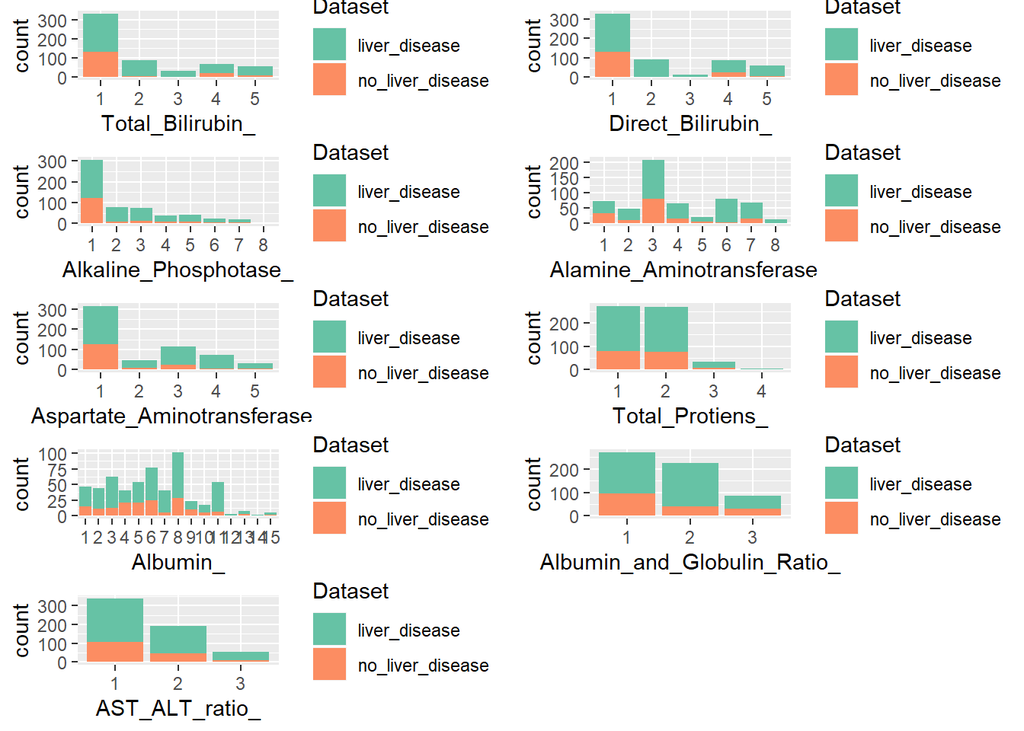

```r
p1 <- ggplot(df.cat.f, aes(x=Total_Bilirubin_)) +
    geom_bar(aes(fill=Dataset)) +
    scale_fill_brewer(palette = "Set2")

p2 <- ggplot(df.cat.f, aes(x=Direct_Bilirubin_)) +
    geom_bar(aes(fill=Dataset)) +
    scale_fill_brewer(palette = "Set2")

p3 <- ggplot(df.cat.f, aes(x=Alkaline_Phosphotase_)) +
    geom_bar(aes(fill=Dataset)) +
    scale_fill_brewer(palette = "Set2")

p4 <- ggplot(df.cat.f, aes(x=Alamine_Aminotransferase_)) +
    geom_bar(aes(fill=Dataset)) +
    scale_fill_brewer(palette = "Set2")

p5 <- ggplot(df.cat.f, aes(x=Aspartate_Aminotransferase_)) +
    geom_bar(aes(fill=Dataset)) +
    scale_fill_brewer(palette = "Set2")

p6 <- ggplot(df.cat.f, aes(x=Total_Protiens_)) +
    geom_bar(aes(fill=Dataset)) +
    scale_fill_brewer(palette = "Set2")

p7 <- ggplot(df.cat.f, aes(x=Albumin_)) +
    geom_bar(aes(fill=Dataset)) +
    scale_fill_brewer(palette = "Set2")

p8 <- ggplot(df.cat.f, aes(x=Albumin_and_Globulin_Ratio_)) +
    geom_bar(aes(fill=Dataset)) +
    scale_fill_brewer(palette = "Set2")

p9 <- ggplot(df.cat.f, aes(x=AST_ALT_ratio_)) +
    geom_bar(aes(fill=Dataset)) +
    scale_fill_brewer(palette = "Set2")

grid.arrange(p1, p2, p3, p4, p5, p6, p7, p8, p9, ncol=2)
```

**After all these procedures, we had the following 4 dataframes:**

-> ORIGINAL DATAFRAME : df.o  
-> ORIGINAL DATAFRAME with LOG TRANSFORMATION: df.o.log  
-> ORIGINAL DATAFRAME with EXTREME VALUES FITTED: df.o.wo  
-> ORIGINAL DATAFRAME CATEGORIZATED BY CLUSTERING: df.cat.f

Correlations between continuous variables (original dataframe):

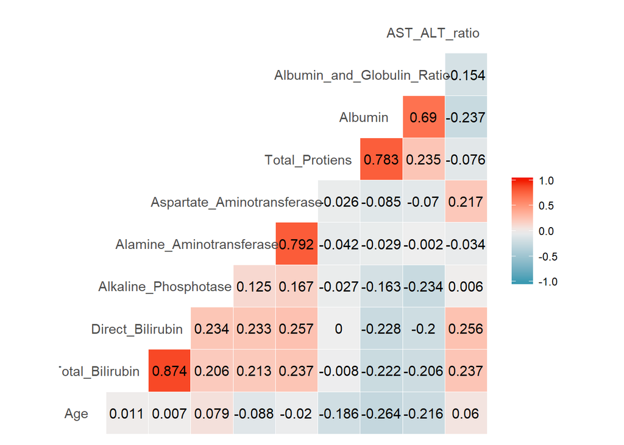

```r
ggcorr(subset(df.o, select = -c(Gender, Dataset)), palette = "RdBu", label = TRUE, label_round = 3, color = "grey30",  hjust = 0.85)
```

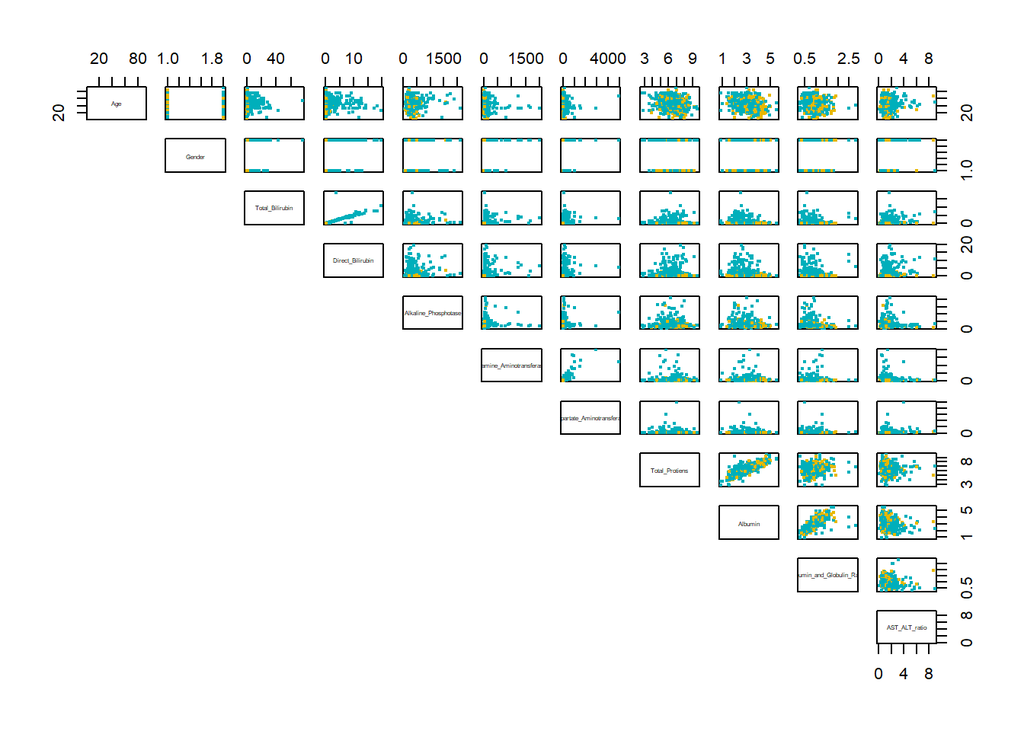

```r
cols <- c("#00AFBB", "#E7B800")
pairs(df.o[,1:11], pch = 19,  cex = 0.4,
      col = cols[df.o$Dataset],
      lower.panel=NULL,
      cex.labels = 0.4)
```

In this case we used only the original dataframe, since the others showed similar results.

Some variables are strong directly correlated:  
-> Total Bilirubin x Direct Bilirubin: 0.874  
-> Alamine Aminotransferase x Aspartate Aminotransferease: 0.792  
-> Total Protiens x Albumin: 0.783

### Part 2 - Statistical Inferences

Some variables have a skewed distribution (not normal). Many of statistical tests require the data to follow a normal distribution (parametric tests). Before using a statistical test, we plotted the Q-Q plot and Shapiro-Wilk’s method (shapiro.test()) to make sure that the test assumptions were met. The data do *not present a normal distribution*, thus we applied non-paramatric tests.

In order to compare the two groups (liver disease and no liver disease - two independent groups of samples) and several variables not normally distributed, we chose the unpaired two-samples Wilcoxon test (also known as Mann-Whitney test). Using the Mann-Whitney-Wilcoxon Test, we can decide whether the population distributions are identical without assuming them to follow the normal distribution.

We tested 3 dataframes (original, original log transformed and original with extreme values fitted) through the Mann-Whitney-Wilcoxon Test.

```r
# df.o
wilcox.tests.o <- lapply(df.o[,c("Total_Bilirubin", "Direct_Bilirubin", "Alkaline_Phosphotase", "Alamine_Aminotransferase", "Aspartate_Aminotransferase", "Total_Protiens", "Albumin", "Albumin_and_Globulin_Ratio", "Age", "AST_ALT_ratio")], function(x) wilcox.test(x ~ df.o$Dataset)$p.value)

#df.o.log
wilcox.tests.o.log <- lapply(df.o.log[,c("Total_Bilirubin", "Direct_Bilirubin", "Alkaline_Phosphotase", "Alamine_Aminotransferase", "Aspartate_Aminotransferase", "Total_Protiens", "Albumin", "Albumin_and_Globulin_Ratio", "Age", "AST_ALT_ratio")], function(x) wilcox.test(x ~ df.o.log$Dataset)$p.value)

#df.o.wo
wilcox.tests.o.wo <- lapply(df.o.wo[,c("Total_Bilirubin", "Direct_Bilirubin", "Alkaline_Phosphotase", "Alamine_Aminotransferase", "Aspartate_Aminotransferase", "Total_Protiens", "Albumin", "Albumin_and_Globulin_Ratio", "Age", "AST_ALT_ratio")], function(x) wilcox.test(x ~ df.o.wo$Dataset)$p.value)

results_wilcox <- cbind(wilcox.tests.o, wilcox.tests.o.log, wilcox.tests.o.wo)
results_wilcox
```

```
##                            wilcox.tests.o wilcox.tests.o.log
## Total_Bilirubin            2.748439e-13   2.748439e-13
## Direct_Bilirubin           6.449568e-13   6.449568e-13
## Alkaline_Phosphotase       9.936943e-11   9.936943e-11
## Alamine_Aminotransferase   3.702919e-12   3.702919e-12
## Aspartate_Aminotransferase 1.310704e-13   1.310704e-13
## Total_Protiens             0.446179       0.446179
## Albumin                    5.931425e-05   5.931425e-05
## Albumin_and_Globulin_Ratio 5.812072e-06   5.812072e-06
## Age                        0.002731931    0.002731931
## AST_ALT_ratio              0.05342674     0.05342674
##                            wilcox.tests.o.wo
## Total_Bilirubin            4.979732e-13
## Direct_Bilirubin           8.72447e-13
## Alkaline_Phosphotase       1.205418e-10
## Alamine_Aminotransferase   4.594092e-12
## Aspartate_Aminotransferase 1.386802e-13
## Total_Protiens             0.4468362
## Albumin                    5.931425e-05
## Albumin_and_Globulin_Ratio 5.690612e-06
## Age                        0.002731931
## AST_ALT_ratio              0.05320489
```

The results were similar for the 3 dataframes (original, log transformed and original with extreme values fitted).

After that, we got the original dataframe with categorization (df.cat.f) and compared categorical variables through the chi-square test of independence (used to analyze the frequency table). The chi-squared test is a statistical test used to discover whether there is a relationship between categorical variables.

```r
chisq.tests <- lapply(df.cat.f[,c("Gender", "Total_Bilirubin_", "Direct_Bilirubin_", "Alkaline_Phosphotase_", "Alamine_Aminotransferase_", "Aspartate_Aminotransferase_", "Total_Protiens_", "Albumin_", "Albumin_and_Globulin_Ratio_", "AST_ALT_ratio_")], function(x) chisq.test(xtabs(~ Dataset + x, df.cat.f))$p.value)
chisq.tests
```

```
## $Gender
## [1] 0.06432014
##
## $Total_Bilirubin_
## [1] 4.65473e-12
##
## $Direct_Bilirubin_
## [1] 1.482585e-12
##
## $Alkaline_Phosphotase_
## [1] 2.575551e-07
##
## $Alamine_Aminotransferase_
## [1] 2.234549e-09
##
## $Aspartate_Aminotransferase_
## [1] 3.965019e-11
##
## $Total_Protiens_
## [1] 0.8337877
##
## $Albumin_
## [1] 0.001863017
##
## $Albumin_and_Globulin_Ratio_
## [1] 3.908695e-05
##
## $AST_ALT_ratio_
## [1] 0.05498922
```

The standardized residuals is also important to interpret the association between rows and columns.

```r
chisq.tests.ind <- chisq.test(xtabs(~ Dataset + Total_Bilirubin_, df.cat.f))
chisq.tests.ind$residuals
```

```
##                   Total_Bilirubin_
## Dataset                     1          2          3          4          5
##   liver_disease    -2.4282417  2.5738834  1.7301178  0.1340244  1.1346229
##   no_liver_disease  3.8463617 -4.0770597 -2.7405257 -0.2122961 -1.7972552
```

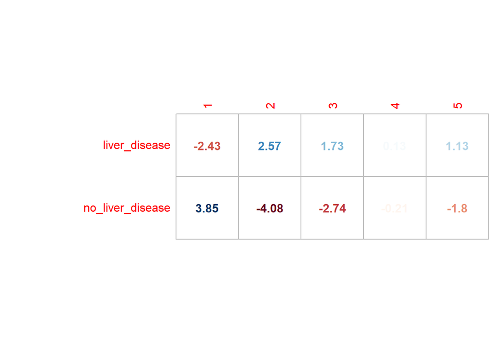

```r
corrplot(chisq.tests.ind$residuals, is.cor = FALSE, method="number",  cl.pos = "n")
```

For example, the residuals of chi-squared test between Dataset (liver_disease and no_liver_disease) and Total Bilirubin shows attraction (positive association) and repulsion (negative association). The group 1 (lower values of Total_Bilirubin), for example, shows a positive association with no_liver_disease and a negative association with liver_disease.

### Part 3 - Features Selection

We used some previous results and some procedures to perform the feature (variable) selection in order to improve the performance of machine learning models.

1. The results from correlation were:  
   -> Total Bilirubin x Direct Bilirubin: + 0.874  
   -> Alamine Aminotransferase x Aspartate Aminotransferease: + 0.792  
   -> Total Protiens x Albumin: + 0.783
2. The results from statistical analysis showed that the variables Total Protiens, Gender and AST_ALT_ratio are not significantly different between no_liver_disease and liver_disease groups.
3. Boruta: It is a feature ranking and selection algorithm based on random forests. It clearly decides if a variable is important or not.

```r
set.seed(123)
boruta_output <- Boruta(Dataset ~ ., data=df.o, doTrace=0)
boruta_output$finalDecision
```

```
##                        Age                     Gender
##                  Confirmed                   Rejected
##            Total_Bilirubin           Direct_Bilirubin
##                  Confirmed                  Confirmed
##       Alkaline_Phosphotase   Alamine_Aminotransferase
##                  Confirmed                  Confirmed
## Aspartate_Aminotransferase             Total_Protiens
##                  Confirmed                   Rejected
##                    Albumin Albumin_and_Globulin_Ratio
##                   Rejected                   Rejected
##              AST_ALT_ratio
##                   Rejected
## Levels: Tentative Confirmed Rejected
```

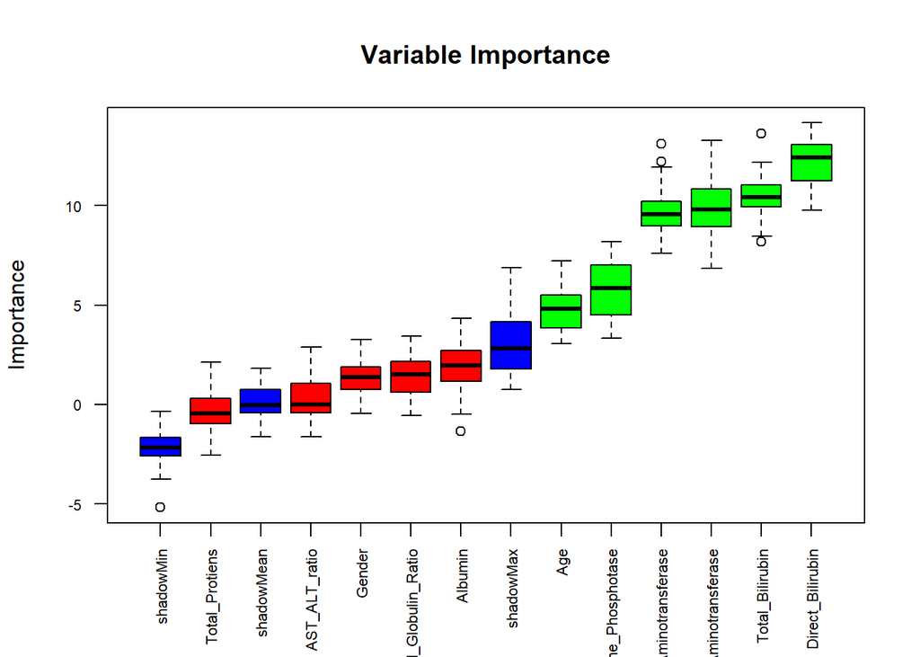

```r
plot(boruta_output, cex.axis=.7, las=2, xlab="", main="Variable Importance")
```

```r
set.seed(123)
boruta_output <- Boruta(Dataset ~ ., data=df.o.wo, doTrace=0)
boruta_output$finalDecision
```

```
##                        Age                     Gender
##                  Confirmed                   Rejected
##            Total_Bilirubin           Direct_Bilirubin
##                  Confirmed                  Confirmed
##       Alkaline_Phosphotase   Alamine_Aminotransferase
##                  Confirmed                  Confirmed
## Aspartate_Aminotransferase             Total_Protiens
##                  Confirmed                   Rejected
##                    Albumin Albumin_and_Globulin_Ratio
##                   Rejected                   Rejected
##              AST_ALT_ratio
##                   Rejected
## Levels: Tentative Confirmed Rejected
```

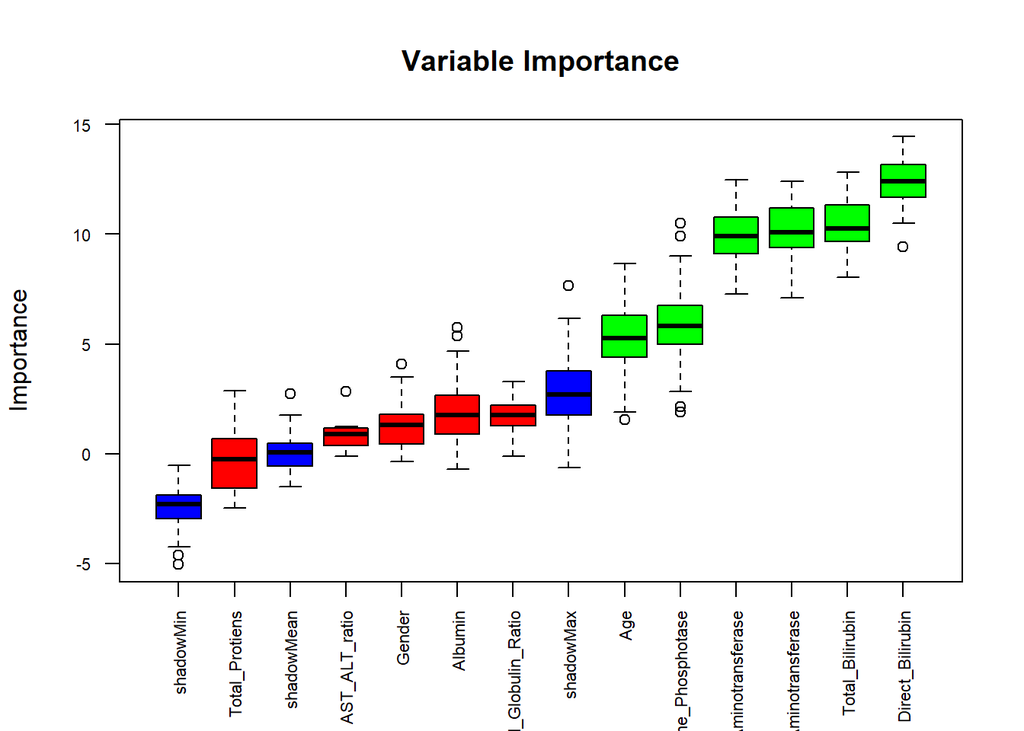

```r
plot(boruta_output, cex.axis=.7, las=2, xlab="", main="Variable Importance")
```

```r
set.seed(123)
boruta_output <- Boruta(Dataset ~ ., data=df.cat.f, doTrace=0)
boruta_output$finalDecision
```

```
##                         Age                      Gender
##                   Confirmed                    Rejected
##            Total_Bilirubin_           Direct_Bilirubin_
##                   Confirmed                   Confirmed
##       Alkaline_Phosphotase_   Alamine_Aminotransferase_
##                   Confirmed                   Confirmed
## Aspartate_Aminotransferase_             Total_Protiens_
##                   Confirmed                    Rejected
##                    Albumin_ Albumin_and_Globulin_Ratio_
##                    Rejected                    Rejected
##              AST_ALT_ratio_
##                    Rejected
## Levels: Tentative Confirmed Rejected
```

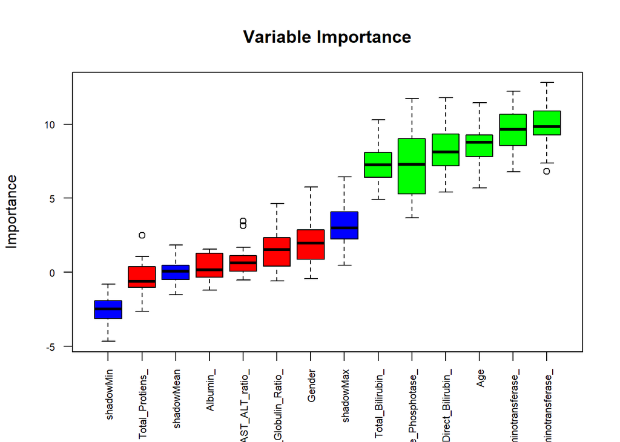

```r
plot(boruta_output, cex.axis=.7, las=2, xlab="", main="Variable Importance")
```

4. Variable Importance Through Random Forest: Random forests are based on decision trees and use bagging to come up with a model over the data.

```r
set.seed(123)
fit=randomForest(Dataset~., data=df.o)
varImp(fit)
```

|  | Overall |
| --- | --- |
| Age | 26.535630 |
| Gender | 3.693215 |
| Total_Bilirubin | 22.710747 |
| Direct_Bilirubin | 17.766657 |
| Alkaline_Phosphotase | 32.105306 |
| Alamine_Aminotransferase | 27.514931 |
| Aspartate_Aminotransferase | 27.301637 |
| Total_Protiens | 19.205809 |
| Albumin | 19.112087 |
| Albumin_and_Globulin_Ratio | 16.517576 |

[output cut: 1 more lines]

```r
set.seed(123)
fit=randomForest(Dataset~., data=df.o.wo)
varImp(fit)
```

|  | Overall |
| --- | --- |
| Age | 26.899831 |
| Gender | 3.425688 |
| Total_Bilirubin | 21.473734 |
| Direct_Bilirubin | 17.213748 |
| Alkaline_Phosphotase | 31.666055 |
| Alamine_Aminotransferase | 27.242888 |
| Aspartate_Aminotransferase | 27.925299 |
| Total_Protiens | 18.759686 |
| Albumin | 19.983295 |
| Albumin_and_Globulin_Ratio | 16.593362 |

[output cut: 1 more lines]

```r
set.seed(123)
fit=randomForest(Dataset~., data=df.cat.f)
varImp(fit)
```

|  | Overall |
| --- | --- |
| Age | 45.918128 |
| Gender | 7.190711 |
| Total_Bilirubin_ | 13.164391 |
| Direct_Bilirubin_ | 15.883589 |
| Alkaline_Phosphotase_ | 21.946325 |
| Alamine_Aminotransferase_ | 27.706936 |
| Aspartate_Aminotransferase_ | 14.005067 |
| Total_Protiens_ | 8.610579 |
| Albumin_ | 38.865566 |
| Albumin_and_Globulin_Ratio_ | 9.843571 |

[output cut: 1 more lines]

5. Using Regression to Calculate Variable Importance: The summary function in regression also describes features and how they affect the dependent feature through significance.

```r
set.seed(123)
model.lr <- glm(Dataset ~ ., data = df.o, family = binomial(link='logit'))
summary(model.lr)
```

```
##
## Call:
## glm(formula = Dataset ~ ., family = binomial(link = "logit"),
##     data = df.o)
##
## Deviance Residuals:
##     Min       1Q   Median       3Q      Max
## -1.4443  -0.8986  -0.3699   1.0723   3.2976
##
## Coefficients:
##                              Estimate Std. Error z value Pr(>|z|)
## (Intercept)                 3.4080440  1.3364579   2.550  0.01077 *
## Age                        -0.0183287  0.0063879  -2.869  0.00411 **
## GenderMale                 -0.0298962  0.2334396  -0.128  0.89810
## Total_Bilirubin            -0.0088230  0.0827364  -0.107  0.91507
## Direct_Bilirubin           -0.4685817  0.2388022  -1.962  0.04974 *
## Alkaline_Phosphotase       -0.0012776  0.0008175  -1.563  0.11811
## Alamine_Aminotransferase   -0.0060124  0.0062308  -0.965  0.33457
## Aspartate_Aminotransferase -0.0076101  0.0050455  -1.508  0.13148
## Total_Protiens             -1.0023827  0.3862528  -2.595  0.00946 **
## Albumin                     1.8699162  0.7609616   2.457  0.01400 *
## Albumin_and_Globulin_Ratio -2.0437179  1.1578805  -1.765  0.07756 .
## AST_ALT_ratio               0.2834311  0.2009464   1.410  0.15840
## ---
## Signif. codes:  0 '***' 0.001 '**' 0.01 '*' 0.05 '.' 0.1 ' ' 1
##
## (Dispersion parameter for binomial family taken to be 1)
##
##     Null deviance: 692.01  on 578  degrees of freedom
## Residual deviance: 565.93  on 567  degrees of freedom
## AIC: 589.93
##
## Number of Fisher Scoring iterations: 7
```

After that, we chose the following variables as essential for the machine learning models: Alkaline_Phosphotase, Alamine_Aminotransferase and Age. Other variables were applied in order to improve the performance. The variable Gender is a non essential variable and was not used.

### Part 4 - Modeling and Predictions

To develop a model to predict liver disease and no liver disease based on patient records, we tried the following 3 dataset and 4 machine learning models:

-> ORIGINAL DATAFRAME: df.o  
-> ORIGINAL DATAFRAME with EXTREME VALUES FITTED: df.o.wo  
-> ORIGINAL DATAFRAME CATEGORIZATED BY CLUSTERING: df.cat.f

```r
# Relevels:
df.o$Dataset <- relevel(df.o$Dataset, "no_liver_disease")
df.o.wo$Dataset <- relevel(df.o.wo$Dataset, "no_liver_disease")
df.cat.f$Dataset <- relevel(df.cat.f$Dataset, "no_liver_disease")
```

#### 1. Logistic Regression:

ORIGINAL DATAFRAME:

```r
# df.o
set.seed(123)
training.samples <- df.o$Dataset %>%
    createDataPartition(p = 0.8, list = FALSE)
df.Train <- df.o[ training.samples,]
df.Test  <- df.o[-training.samples,]

# Model
set.seed(123)
model.lr.o <- glm(Dataset ~ Total_Bilirubin + Alkaline_Phosphotase + Alamine_Aminotransferase + Total_Protiens + Albumin + Age, data = df.Train, family = binomial(link='logit'))
summary(model.lr.o)
```

```
##
## Call:
## glm(formula = Dataset ~ Total_Bilirubin + Alkaline_Phosphotase +
##     Alamine_Aminotransferase + Total_Protiens + Albumin + Age,
##     family = binomial(link = "logit"), data = df.Train)
##
## Deviance Residuals:
##     Min       1Q   Median       3Q      Max
## -3.0560  -1.1370   0.4463   0.9076   1.4566
##
## Coefficients:
##                            Estimate Std. Error z value Pr(>|z|)
## (Intercept)              -1.5301209  0.8769951  -1.745  0.08103 .
## Total_Bilirubin           0.2601250  0.1002763   2.594  0.00948 **
## Alkaline_Phosphotase      0.0009163  0.0008615   1.064  0.28752
## Alamine_Aminotransferase  0.0141188  0.0044700   3.159  0.00159 **
## Total_Protiens            0.4487603  0.2028569   2.212  0.02695 *
## Albumin                  -0.7214425  0.2883465  -2.502  0.01235 *
## Age                       0.0124358  0.0071520   1.739  0.08207 .
## ---
## Signif. codes:  0 '***' 0.001 '**' 0.01 '*' 0.05 '.' 0.1 ' ' 1
##
## (Dispersion parameter for binomial family taken to be 1)
##
##     Null deviance: 554.14  on 463  degrees of freedom
## Residual deviance: 467.20  on 457  degrees of freedom
## AIC: 481.2
##
## Number of Fisher Scoring iterations: 7
```

The logistic regression coefficients give the change in the log odds of the outcome for a single unit increase in the predictor variable.

The coefficient estimate of the variable Alamine_Aminotransferase is b = 0.0141188, which is positive. This means that an increase in Alamine Aminotransferase lab test is associated with increase in the probability of having liver disease. This indicates that one unit increase in the Alamine_Aminotransferase unit will increase the odds of having liver disease by exp(0.0141188) 1.014219 times.

However the coefficient for the variable Albumin is b = 0.7214425, which is negative. This means that an increase in Albumin lab test will be associated with a decreased probability of having liver disease.

```r
# Prediction
probabilities <- model.lr.o %>% predict(df.Test, type = "response")
predicted.classes <- ifelse(probabilities > 0.5, "liver_disease", "no_liver_disease")
matrix.lr.o <- confusionMatrix(relevel(as.factor(predicted.classes), "no_liver_disease"), df.Test$Dataset)
matrix.lr.o
```

```
## Confusion Matrix and Statistics
##
##                   Reference
## Prediction         no_liver_disease liver_disease
##   no_liver_disease                8             3
##   liver_disease                  25            79
##
##                Accuracy : 0.7565
##                  95% CI : (0.6677, 0.8317)
##     No Information Rate : 0.713
##     P-Value [Acc > NIR] : 0.1773
##
##                   Kappa : 0.257
##
##  Mcnemar's Test P-Value : 7.229e-05
##
##             Sensitivity : 0.24242
##             Specificity : 0.96341
##          Pos Pred Value : 0.72727
##          Neg Pred Value : 0.75962
##              Prevalence : 0.28696
##          Detection Rate : 0.06957
##    Detection Prevalence : 0.09565
##       Balanced Accuracy : 0.60292
##
##        'Positive' Class : no_liver_disease
##
```

ORIGINAL DATAFRAME with EXTREME VALUES FITTED:

```r
# df.o.wo
set.seed(123)
training.samples <- df.o.wo$Dataset %>%
    createDataPartition(p = 0.8, list = FALSE)
df.Train <- df.o.wo[ training.samples,]
df.Test  <- df.o.wo[-training.samples,]

# Model
set.seed(123)
model.lr.o.wo <- glm(Dataset ~ Total_Bilirubin + Alkaline_Phosphotase + Alamine_Aminotransferase + Total_Protiens + Albumin + Age, data = df.Train, family = binomial(link='logit'))
summary(model.lr.o.wo)
```

```
##
## Call:
## glm(formula = Dataset ~ Total_Bilirubin + Alkaline_Phosphotase +
##     Alamine_Aminotransferase + Total_Protiens + Albumin + Age,
##     family = binomial(link = "logit"), data = df.Train)
##
## Deviance Residuals:
##     Min       1Q   Median       3Q      Max
## -3.0629  -1.0925   0.4238   0.8898   1.4153
##
## Coefficients:
##                           Estimate Std. Error z value Pr(>|z|)
## (Intercept)              -1.962726   0.911032  -2.154  0.03121 *
## Total_Bilirubin           0.371582   0.123149   3.017  0.00255 **
## Alkaline_Phosphotase      0.002383   0.001468   1.624  0.10445
## Alamine_Aminotransferase  0.017826   0.005253   3.394  0.00069 ***
## Total_Protiens            0.425329   0.207456   2.050  0.04034 *
## Albumin                  -0.699251   0.289766  -2.413  0.01581 *
## Age                       0.012225   0.007225   1.692  0.09063 .
## ---
## Signif. codes:  0 '***' 0.001 '**' 0.01 '*' 0.05 '.' 0.1 ' ' 1
##
## (Dispersion parameter for binomial family taken to be 1)
##
##     Null deviance: 554.14  on 463  degrees of freedom
## Residual deviance: 469.53  on 457  degrees of freedom
## AIC: 483.53
##
## Number of Fisher Scoring iterations: 5
```

```r
# Prediction
probabilities <- model.lr.o.wo %>% predict(df.Test, type = "response")
predicted.classes <- ifelse(probabilities > 0.5, "liver_disease", "no_liver_disease")
matrix.lr.o.wo <- confusionMatrix(relevel(as.factor(predicted.classes), "no_liver_disease"), df.Test$Dataset)
matrix.lr.o.wo
```

```
## Confusion Matrix and Statistics
##
##                   Reference
## Prediction         no_liver_disease liver_disease
##   no_liver_disease                7             4
##   liver_disease                  26            78
##
##                Accuracy : 0.7391
##                  95% CI : (0.649, 0.8166)
##     No Information Rate : 0.713
##     P-Value [Acc > NIR] : 0.307050
##
##                   Kappa : 0.204
##
##  Mcnemar's Test P-Value : 0.000126
##
##             Sensitivity : 0.21212
##             Specificity : 0.95122
##          Pos Pred Value : 0.63636
##          Neg Pred Value : 0.75000
##              Prevalence : 0.28696
##          Detection Rate : 0.06087
##    Detection Prevalence : 0.09565
##       Balanced Accuracy : 0.58167
##
##        'Positive' Class : no_liver_disease
##
```

ORIGINAL DATAFRAME CATEGORIZATED BY CLUSTERING:

```r
# df.cat.f
set.seed(123)
training.samples <- df.cat.f$Dataset %>%
    createDataPartition(p = 0.8, list = FALSE)
df.Train <- df.cat.f[ training.samples,]
df.Test  <- df.cat.f[-training.samples,]

# Model
set.seed(123)
model.lr.cat.f <- glm(Dataset ~ Total_Bilirubin_ + Alkaline_Phosphotase_ + Alamine_Aminotransferase_ + Total_Protiens_ + Albumin_ + AST_ALT_ratio_ + Age, data = df.Train, family = binomial(link='logit'))
summary(model.lr.cat.f)
```

```
##
## Call:
## glm(formula = Dataset ~ Total_Bilirubin_ + Alkaline_Phosphotase_ +
##     Alamine_Aminotransferase_ + Total_Protiens_ + Albumin_ +
##     AST_ALT_ratio_ + Age, family = binomial(link = "logit"),
##     data = df.Train)
##
## Deviance Residuals:
##     Min       1Q   Median       3Q      Max
## -2.4503  -0.9005   0.3412   0.8109   1.7160
##
## Coefficients:
##                              Estimate Std. Error z value Pr(>|z|)
## (Intercept)                  -0.83655    0.72232  -1.158  0.24681
## Total_Bilirubin_2             1.56289    0.67550   2.314  0.02069 *
## Total_Bilirubin_3             2.39512    1.10038   2.177  0.02951 *
## Total_Bilirubin_4             0.46522    0.39279   1.184  0.23625
## Total_Bilirubin_5             0.61428    0.48803   1.259  0.20814
## Alkaline_Phosphotase_2        1.02107    0.55747   1.832  0.06701 .
## Alkaline_Phosphotase_3        1.18056    0.46818   2.522  0.01168 *
## Alkaline_Phosphotase_4        0.59752    0.69930   0.854  0.39285
## Alkaline_Phosphotase_5        1.17630    0.53285   2.208  0.02727 *
## Alkaline_Phosphotase_6        0.78974    0.62828   1.257  0.20876
## Alkaline_Phosphotase_7        0.94752    0.76184   1.244  0.21360
## Alkaline_Phosphotase_8       17.02015 1695.91908   0.010  0.99199
## Alamine_Aminotransferase_2    0.65183    0.61216   1.065  0.28696
## Alamine_Aminotransferase_3    0.18871    0.35552   0.531  0.59555
## Alamine_Aminotransferase_4    0.67579    0.48107   1.405  0.16009
## Alamine_Aminotransferase_5    0.47278    0.73630   0.642  0.52081
## Alamine_Aminotransferase_6    2.14188    0.74120   2.890  0.00386 **
## Alamine_Aminotransferase_7    1.10195    0.48084   2.292  0.02192 *
## Alamine_Aminotransferase_8   15.54052  744.62293   0.021  0.98335
## Total_Protiens_2             -0.81781    0.36992  -2.211  0.02705 *
## Total_Protiens_3             -0.46540    0.79618  -0.585  0.55886
## Total_Protiens_4              1.00999    1.60542   0.629  0.52927
## Albumin_2                     0.47359    0.65914   0.719  0.47245
## Albumin_3                     1.21849    0.65234   1.868  0.06178 .
## Albumin_4                    -0.68956    0.67277  -1.025  0.30539
## Albumin_5                    -0.01767    0.58930  -0.030  0.97607
## Albumin_6                    -0.19420    0.58830  -0.330  0.74132
## Albumin_7                     0.91629    0.73916   1.240  0.21511
## Albumin_8                     0.57411    0.55271   1.039  0.29894
## Albumin_9                    -1.10415    0.80201  -1.377  0.16860
## Albumin_10                    0.02867    0.98040   0.029  0.97667
## Albumin_11                    1.51940    0.80575   1.886  0.05934 .
## Albumin_12                   14.34127 1328.79163   0.011  0.99139
## Albumin_13                    0.06867    1.13465   0.061  0.95174
## Albumin_14                   15.99617 1691.93583   0.009  0.99246
## Albumin_15                   -1.02355    1.26536  -0.809  0.41857
## AST_ALT_ratio_2              -0.19849    0.27583  -0.720  0.47176
## AST_ALT_ratio_3              -0.26080    0.56640  -0.460  0.64519
## Age                           0.01653    0.00796   2.077  0.03785 *
## ---
## Signif. codes:  0 '***' 0.001 '**' 0.01 '*' 0.05 '.' 0.1 ' ' 1
##
## (Dispersion parameter for binomial family taken to be 1)
##
##     Null deviance: 554.14  on 463  degrees of freedom
## Residual deviance: 429.68  on 425  degrees of freedom
## AIC: 507.68
##
## Number of Fisher Scoring iterations: 15
```

```r
# Prediction
probabilities <- model.lr.cat.f %>% predict(df.Test, type = "response")
predicted.classes <- ifelse(probabilities > 0.5, "liver_disease", "no_liver_disease")
matrix.lr.cat.f <- confusionMatrix(relevel(as.factor(predicted.classes), "no_liver_disease"), df.Test$Dataset)
matrix.lr.cat.f
```

```
## Confusion Matrix and Statistics
##
##                   Reference
## Prediction         no_liver_disease liver_disease
##   no_liver_disease               16             9
##   liver_disease                  17            73
##
##                Accuracy : 0.7739
##                  95% CI : (0.6865, 0.8467)
##     No Information Rate : 0.713
##     P-Value [Acc > NIR] : 0.08794
##
##                   Kappa : 0.4044
##
##  Mcnemar's Test P-Value : 0.16981
##
##             Sensitivity : 0.4848
##             Specificity : 0.8902
##          Pos Pred Value : 0.6400
##          Neg Pred Value : 0.8111
##              Prevalence : 0.2870
##          Detection Rate : 0.1391
##    Detection Prevalence : 0.2174
##       Balanced Accuracy : 0.6875
##
##        'Positive' Class : no_liver_disease
##
```

This model performed better with the ORIGINAL DATAFRAME CATEGORIZATED BY CLUSTERING - The overall accuracy was 77,39%. The accuracy represents the correct classification of patients with and without the condition (prediction x reference).

#### 2. KNN (K-Nearest Neighbors):

ORIGINAL DATAFRAME:

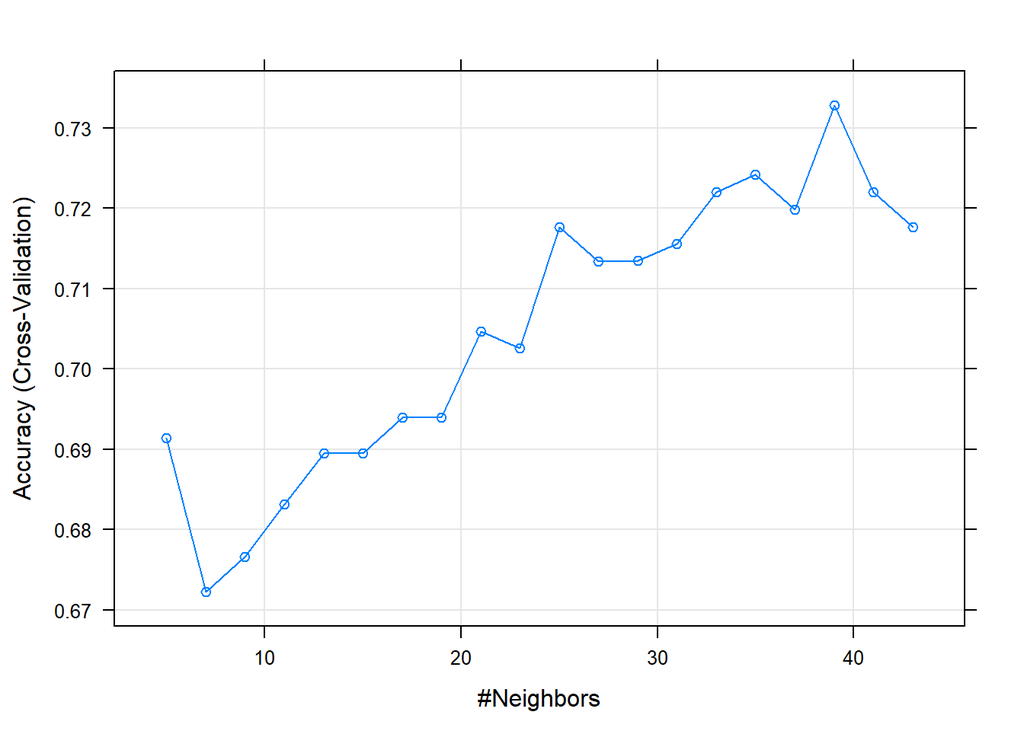

```r
# df.o
set.seed(123)
training.samples <- df.o$Dataset %>%
    createDataPartition(p = 0.8, list = FALSE)
df.Train <- df.o[ training.samples,]
df.Test  <- df.o[-training.samples,]

# Model
set.seed(123)
model.knn.o <- train(
  Dataset ~ Total_Bilirubin + Alkaline_Phosphotase + Alamine_Aminotransferase + Total_Protiens + Albumin + Age, data = df.Train, method = "knn",
  trControl = trainControl("cv", number = 10),
  preProcess = c("center","scale"), #no for categoric
  tuneLength = 20
  )
plot(model.knn.o)
```

```r
# Prediction
predicted.classes <- model.knn.o %>% predict(df.Test)
matrix.knn.o <- confusionMatrix(predicted.classes, df.Test$Dataset)
matrix.knn.o
```

```
## Confusion Matrix and Statistics
##
##                   Reference
## Prediction         no_liver_disease liver_disease
##   no_liver_disease                5             5
##   liver_disease                  28            77
##
##                Accuracy : 0.713
##                  95% CI : (0.6212, 0.7935)
##     No Information Rate : 0.713
##     P-Value [Acc > NIR] : 0.5467811
##
##                   Kappa : 0.1144
##
##  Mcnemar's Test P-Value : 0.0001283
##
##             Sensitivity : 0.15152
##             Specificity : 0.93902
##          Pos Pred Value : 0.50000
##          Neg Pred Value : 0.73333
##              Prevalence : 0.28696
##          Detection Rate : 0.04348
##    Detection Prevalence : 0.08696
##       Balanced Accuracy : 0.54527
##
##        'Positive' Class : no_liver_disease
##
```

ORIGINAL DATAFRAME with EXTREME VALUES FITTED:

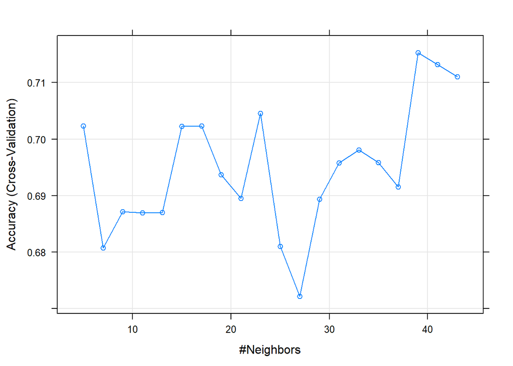

```r
# df.o.wo
set.seed(123)
training.samples <- df.o.wo$Dataset %>%
    createDataPartition(p = 0.8, list = FALSE)
df.Train <- df.o.wo[ training.samples,]
df.Test  <- df.o.wo[-training.samples,]

# Model
set.seed(123)
model.knn.o.wo <- train(
  Dataset ~ Total_Bilirubin + Alkaline_Phosphotase + Alamine_Aminotransferase + Total_Protiens + Age, data = df.Train, method = "knn",
  trControl = trainControl("cv", number = 10),
  preProcess = c("center","scale"), #no for categoric
  tuneLength = 20
  )
plot(model.knn.o.wo)
```

```r
# Prediction
predicted.classes <- model.knn.o.wo %>% predict(df.Test)
matrix.knn.o.wo <- confusionMatrix(predicted.classes, df.Test$Dataset)
matrix.knn.o.wo
```

```
## Confusion Matrix and Statistics
##
##                   Reference
## Prediction         no_liver_disease liver_disease
##   no_liver_disease                5            12
##   liver_disease                  28            70
##
##                Accuracy : 0.6522
##                  95% CI : (0.5577, 0.7386)
##     No Information Rate : 0.713
##     P-Value [Acc > NIR] : 0.93683
##
##                   Kappa : 0.0061
##
##  Mcnemar's Test P-Value : 0.01771
##
##             Sensitivity : 0.15152
##             Specificity : 0.85366
##          Pos Pred Value : 0.29412
##          Neg Pred Value : 0.71429
##              Prevalence : 0.28696
##          Detection Rate : 0.04348
##    Detection Prevalence : 0.14783
##       Balanced Accuracy : 0.50259
##
##        'Positive' Class : no_liver_disease
##
```

ORIGINAL DATAFRAME CATEGORIZATED BY CLUSTERING:

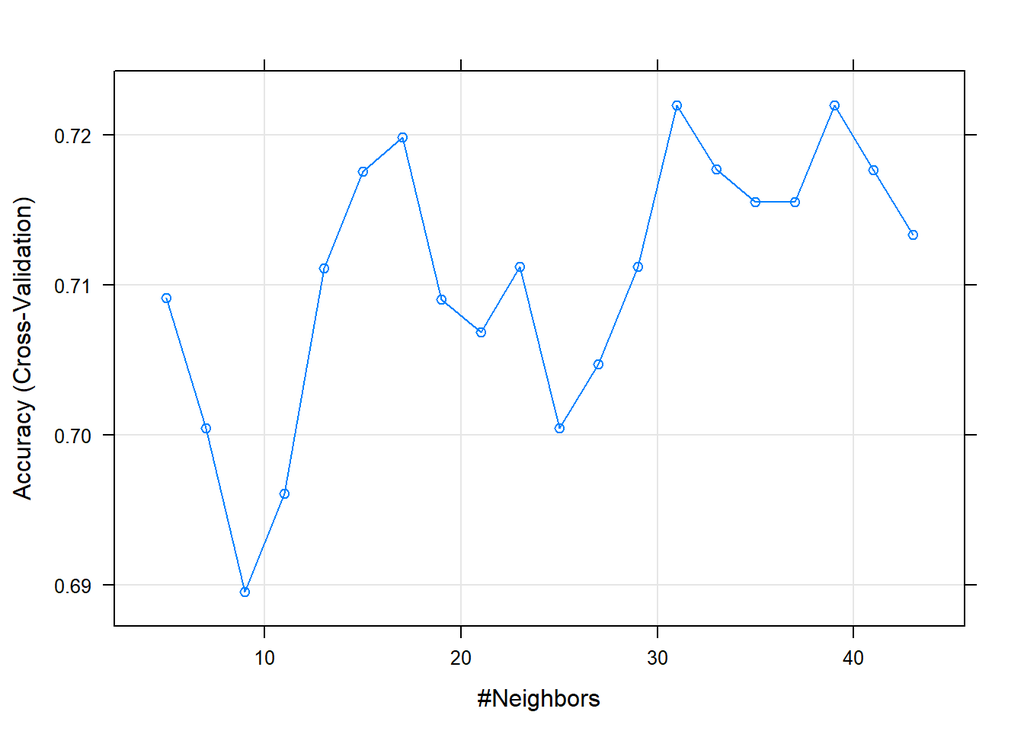

```r
# df.cat.f
set.seed(123)
training.samples <- df.cat.f$Dataset %>%
    createDataPartition(p = 0.8, list = FALSE)
df.Train <- df.cat.f[ training.samples,]
df.Test  <- df.cat.f[-training.samples,]

# Model
set.seed(123)
model.knn.cat.f <- train(
  Dataset ~ Direct_Bilirubin_ + Alkaline_Phosphotase_ + Alamine_Aminotransferase_ + Albumin_ + AST_ALT_ratio_ + Age, data = df.Train, method = "knn",
  trControl = trainControl("cv", number = 10),
  tuneLength = 20
  )
plot(model.knn.cat.f)
```

```r
# Prediction
predicted.classes <- model.knn.cat.f %>% predict(df.Test)
matrix.knn.cat.f <- confusionMatrix(predicted.classes, df.Test$Dataset)
matrix.knn.cat.f
```

```
## Confusion Matrix and Statistics
##
##                   Reference
## Prediction         no_liver_disease liver_disease
##   no_liver_disease                1             3
##   liver_disease                  32            79
##
##                Accuracy : 0.6957
##                  95% CI : (0.6029, 0.778)
##     No Information Rate : 0.713
##     P-Value [Acc > NIR] : 0.7005
##
##                   Kappa : -0.0085
##
##  Mcnemar's Test P-Value : 2.214e-06
##
##             Sensitivity : 0.030303
##             Specificity : 0.963415
##          Pos Pred Value : 0.250000
##          Neg Pred Value : 0.711712
##              Prevalence : 0.286957
##          Detection Rate : 0.008696
##    Detection Prevalence : 0.034783
##       Balanced Accuracy : 0.496859
##
##        'Positive' Class : no_liver_disease
##
```

This model performed better with the ORIGINAL DATAFRAME - The overall accuracy was 71.30%.

#### 3. Classification and Regression Trees (CART):

ORIGINAL DATAFRAME:

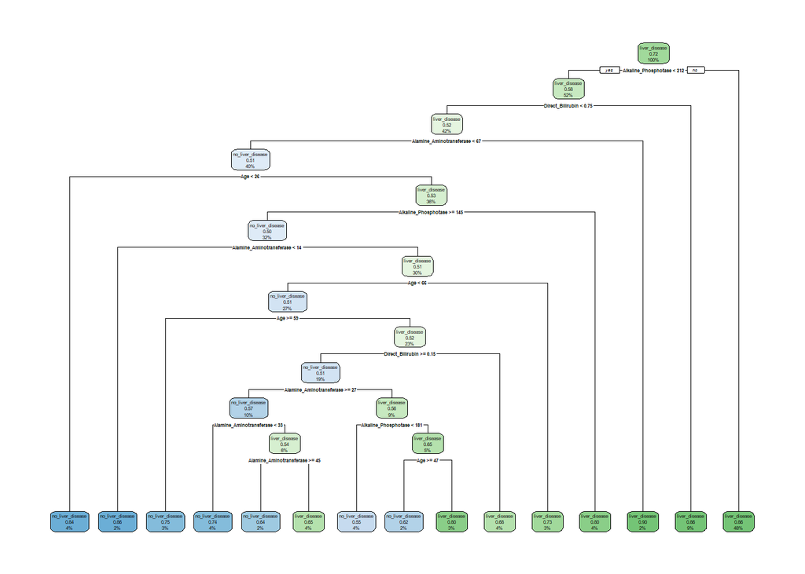

```r
# df.o
set.seed(123)
training.samples <- df.o$Dataset %>%
    createDataPartition(p = 0.8, list = FALSE)
df.Train <- df.o[ training.samples,]
df.Test  <- df.o[-training.samples,]

# Model
set.seed(123)
model.tree.o <- rpart(
  Dataset ~ Direct_Bilirubin + Alkaline_Phosphotase + Alamine_Aminotransferase + Age, data = df.Train, method = "class"
  )
rpart.plot(model.tree.o, cex = NULL, tweak = 1, extra=108)
```

```r
printcp(model.tree.o)
```

```
##
## Classification tree:
## rpart(formula = Dataset ~ Direct_Bilirubin + Alkaline_Phosphotase +
##     Alamine_Aminotransferase + Age, data = df.Train, method = "class")
##
## Variables actually used in tree construction:
## [1] Age                      Alamine_Aminotransferase
## [3] Alkaline_Phosphotase     Direct_Bilirubin
##
## Root node error: 132/464 = 0.28448
##
## n= 464
##
##         CP nsplit rel error xerror     xstd
## 1 0.024621      0   1.00000 1.0000 0.073625
## 2 0.018939     10   0.75000 1.1061 0.075780
## 3 0.015152     12   0.71212 1.1061 0.075780
## 4 0.010000     14   0.68182 1.0682 0.075055
```

```r
# Prediction
predicted.classes <- model.tree.o %>% predict(df.Test, type = "class")
matrix.tree.o <- confusionMatrix(predicted.classes, df.Test$Dataset)
matrix.tree.o
```

```
## Confusion Matrix and Statistics
##
##                   Reference
## Prediction         no_liver_disease liver_disease
##   no_liver_disease               13            16
##   liver_disease                  20            66
##
##                Accuracy : 0.687
##                  95% CI : (0.5938, 0.7702)
##     No Information Rate : 0.713
##     P-Value [Acc > NIR] : 0.7668
##
##                   Kappa : 0.2063
##
##  Mcnemar's Test P-Value : 0.6171
##
##             Sensitivity : 0.3939
##             Specificity : 0.8049
##          Pos Pred Value : 0.4483
##          Neg Pred Value : 0.7674
##              Prevalence : 0.2870
##          Detection Rate : 0.1130
##    Detection Prevalence : 0.2522
##       Balanced Accuracy : 0.5994
##
##        'Positive' Class : no_liver_disease
##
```

ORIGINAL DATAFRAME with EXTREME VALUES FITTED:

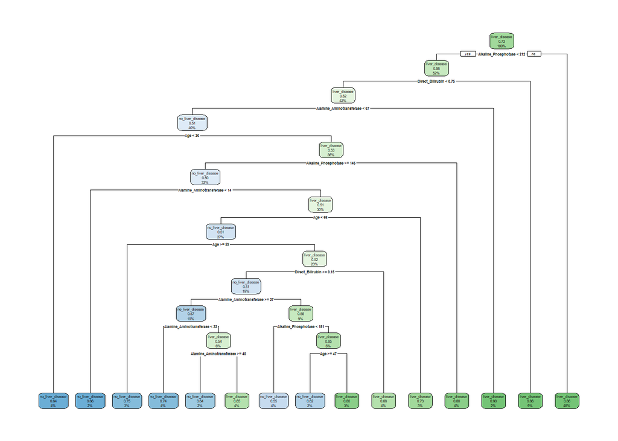

```r
# df.o.wo
set.seed(123)
training.samples <- df.o.wo$Dataset %>%
    createDataPartition(p = 0.8, list = FALSE)
df.Train <- df.o.wo[ training.samples,]
df.Test  <- df.o.wo[-training.samples,]

# Model
set.seed(123)
model.tree.o.wo <- rpart(
  Dataset ~ Direct_Bilirubin + Alkaline_Phosphotase + Alamine_Aminotransferase + Age, data = df.Train, method = "class"
  )
rpart.plot(model.tree.o.wo, cex = NULL, tweak = 1, extra=108)
```

```r
printcp(model.tree.o.wo)
```

```
##
## Classification tree:
## rpart(formula = Dataset ~ Direct_Bilirubin + Alkaline_Phosphotase +
##     Alamine_Aminotransferase + Age, data = df.Train, method = "class")
##
## Variables actually used in tree construction:
## [1] Age                      Alamine_Aminotransferase
## [3] Alkaline_Phosphotase     Direct_Bilirubin
##
## Root node error: 132/464 = 0.28448
##
## n= 464
##
##         CP nsplit rel error xerror     xstd
## 1 0.024621      0   1.00000 1.0000 0.073625
## 2 0.018939     10   0.75000 1.1061 0.075780
## 3 0.015152     12   0.71212 1.1061 0.075780
## 4 0.010000     14   0.68182 1.0682 0.075055
```

```r
# Prediction
predicted.classes <- model.tree.o.wo %>% predict(df.Test, type = "class")
matrix.tree.o.wo <- confusionMatrix(predicted.classes, df.Test$Dataset)
matrix.tree.o.wo
```

```
## Confusion Matrix and Statistics
##
##                   Reference
## Prediction         no_liver_disease liver_disease
##   no_liver_disease               13            16
##   liver_disease                  20            66
##
##                Accuracy : 0.687
##                  95% CI : (0.5938, 0.7702)
##     No Information Rate : 0.713
##     P-Value [Acc > NIR] : 0.7668
##
##                   Kappa : 0.2063
##
##  Mcnemar's Test P-Value : 0.6171
##
##             Sensitivity : 0.3939
##             Specificity : 0.8049
##          Pos Pred Value : 0.4483
##          Neg Pred Value : 0.7674
##              Prevalence : 0.2870
##          Detection Rate : 0.1130
##    Detection Prevalence : 0.2522
##       Balanced Accuracy : 0.5994
##
##        'Positive' Class : no_liver_disease
##
```

ORIGINAL DATAFRAME CATEGORIZATED BY CLUSTERING:

```r
# df.cat.f
set.seed(123)
training.samples <- df.cat.f$Dataset %>%
    createDataPartition(p = 0.8, list = FALSE)
df.Train <- df.cat.f[ training.samples,]
df.Test  <- df.cat.f[-training.samples,]

# Model
set.seed(123)
model.tree.cat.f <- rpart(
  Dataset ~ Alkaline_Phosphotase_ + Alamine_Aminotransferase_ + Albumin_ + Age, data = df.Train, method = "class"
  )
printcp(model.tree.cat.f)
```

```
##
## Classification tree:
## rpart(formula = Dataset ~ Alkaline_Phosphotase_ + Alamine_Aminotransferase_ +
##     Albumin_ + Age, data = df.Train, method = "class")
##
## Variables actually used in tree construction:
## [1] Age                       Alamine_Aminotransferase_
## [3] Albumin_                  Alkaline_Phosphotase_
##
## Root node error: 132/464 = 0.28448
##
## n= 464
##
##         CP nsplit rel error xerror     xstd
## 1 0.027778      0   1.00000 1.0000 0.073625
## 2 0.026515      5   0.83333 1.0682 0.075055
## 3 0.018939      7   0.78030 1.0909 0.075496
## 4 0.015152      9   0.74242 1.1136 0.075920
## 5 0.012626     10   0.72727 1.1288 0.076193
## 6 0.011364     14   0.66667 1.1742 0.076968
## 7 0.010000     16   0.64394 1.1742 0.076968
```

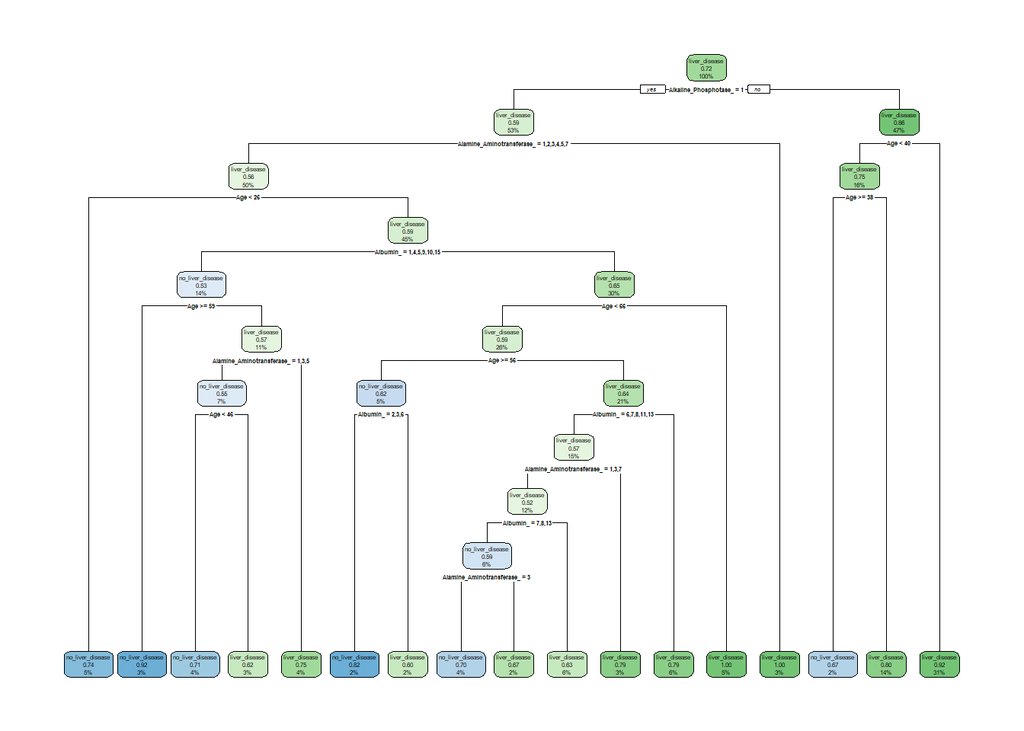

```r
rpart.plot(model.tree.cat.f, cex = NULL, tweak = 1, extra=108)
```

```r
# Prediction
predicted.classes <- model.tree.cat.f %>% predict(df.Test, type = "class")
matrix.tree.cat.f <- confusionMatrix(predicted.classes, df.Test$Dataset)
matrix.tree.cat.f
```

```
## Confusion Matrix and Statistics
##
##                   Reference
## Prediction         no_liver_disease liver_disease
##   no_liver_disease               13            21
##   liver_disease                  20            61
##
##                Accuracy : 0.6435
##                  95% CI : (0.5488, 0.7306)
##     No Information Rate : 0.713
##     P-Value [Acc > NIR] : 0.9579
##
##                   Kappa : 0.1366
##
##  Mcnemar's Test P-Value : 1.0000
##
##             Sensitivity : 0.3939
##             Specificity : 0.7439
##          Pos Pred Value : 0.3824
##          Neg Pred Value : 0.7531
##              Prevalence : 0.2870
##          Detection Rate : 0.1130
##    Detection Prevalence : 0.2957
##       Balanced Accuracy : 0.5689
##
##        'Positive' Class : no_liver_disease
##
```

This model performed better with the ORIGINAL DATAFRAME - The overall accuracy was 68.70%.

#### 4. Random Forest:

ORIGINAL DATAFRAME:

```r
# df.o
set.seed(123)
training.samples <- df.o$Dataset %>%
    createDataPartition(p = 0.8, list = FALSE)
df.Train <- df.o[ training.samples,]
df.Test  <- df.o[-training.samples,]

# Model
set.seed(123)
model.rf.o <- train(
  Dataset ~ Direct_Bilirubin + Total_Bilirubin + Alkaline_Phosphotase + Alamine_Aminotransferase + Albumin + Age + Aspartate_Aminotransferase + Albumin_and_Globulin_Ratio, data = df.Train, method = "rf",
  trControl = trainControl("cv", number = 10),
  importance = FALSE
  )
model.rf.o$finalModel
```

```
##
## Call:
##  randomForest(x = x, y = y, mtry = param$mtry, importance = FALSE)
##                Type of random forest: classification
##                      Number of trees: 500
## No. of variables tried at each split: 5
##
##         OOB estimate of  error rate: 31.25%
## Confusion matrix:
##                  no_liver_disease liver_disease class.error
## no_liver_disease               44            88   0.6666667
## liver_disease                  57           275   0.1716867
```

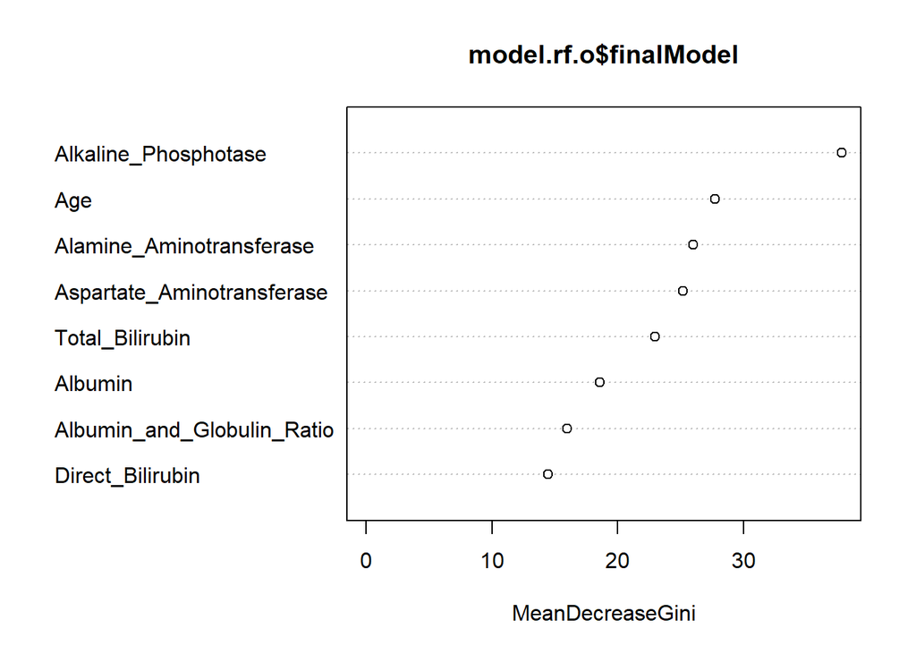

```r
# Plot MeanDecreaseGini
varImpPlot(model.rf.o$finalModel, type = 2)
```

```r
varImp(model.rf.o)
```

```
## rf variable importance
##
##                            Overall
## Alkaline_Phosphotase       100.000
## Age                         56.839
## Alamine_Aminotransferase    49.489
## Aspartate_Aminotransferase  46.045
## Total_Bilirubin             36.432
## Albumin                     17.744
## Albumin_and_Globulin_Ratio   6.483
## Direct_Bilirubin             0.000
```

The results show that across all of the trees considered in the random forest, the Alkaline_Phosphotase, Age and Alamine_Aminotransferase variables are the three most important variables.

```r
# Prediction
predicted.classes <- model.rf.o %>% predict(df.Test)
matrix.rf.o <- confusionMatrix(predicted.classes, df.Test$Dataset)
matrix.rf.o
```

```
## Confusion Matrix and Statistics
##
##                   Reference
## Prediction         no_liver_disease liver_disease
##   no_liver_disease               14            11
##   liver_disease                  19            71
##
##                Accuracy : 0.7391
##                  95% CI : (0.649, 0.8166)
##     No Information Rate : 0.713
##     P-Value [Acc > NIR] : 0.3071
##
##                   Kappa : 0.3127
##
##  Mcnemar's Test P-Value : 0.2012
##
##             Sensitivity : 0.4242
##             Specificity : 0.8659
##          Pos Pred Value : 0.5600
##          Neg Pred Value : 0.7889
##              Prevalence : 0.2870
##          Detection Rate : 0.1217
##    Detection Prevalence : 0.2174
##       Balanced Accuracy : 0.6450
##
##        'Positive' Class : no_liver_disease
##
```

ORIGINAL DATAFRAME with EXTREME VALUES FITTED:

```r
# df.o.wo
set.seed(123)
training.samples <- df.o.wo$Dataset %>%
    createDataPartition(p = 0.8, list = FALSE)
df.Train <- df.o.wo[ training.samples,]
df.Test  <- df.o.wo[-training.samples,]

# Model
set.seed(123)
model.rf.o.wo <- train(
  Dataset ~ Total_Bilirubin + Alkaline_Phosphotase + Alamine_Aminotransferase + Albumin + Aspartate_Aminotransferase + Albumin_and_Globulin_Ratio + Age, data = df.Train, method = "rf",
  trControl = trainControl("cv", number = 10),
  importance = FALSE
  )
model.rf.o.wo$finalModel
```

```
##
## Call:
##  randomForest(x = x, y = y, mtry = param$mtry, importance = FALSE)
##                Type of random forest: classification
##                      Number of trees: 500
## No. of variables tried at each split: 4
##
##         OOB estimate of  error rate: 31.25%
## Confusion matrix:
##                  no_liver_disease liver_disease class.error
## no_liver_disease               42            90   0.6818182
## liver_disease                  55           277   0.1656627
```

```r
# Variable Importance
varImp(model.rf.o.wo)
```

```
## rf variable importance
##
##                            Overall
## Alkaline_Phosphotase        100.00
## Age                          70.83
## Total_Bilirubin              62.27
## Aspartate_Aminotransferase   60.32
## Alamine_Aminotransferase     56.29
## Albumin                      17.59
## Albumin_and_Globulin_Ratio    0.00
```

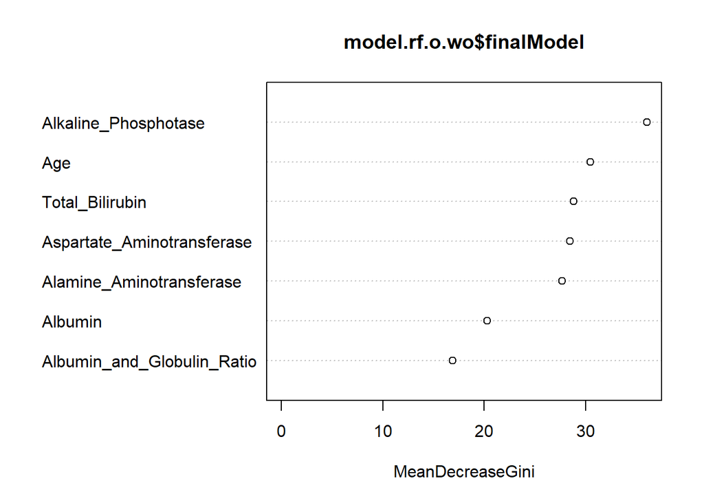

```r
# Plot MeanDecreaseGini
varImpPlot(model.rf.o.wo$finalModel, type = 2)
```

```r
# Prediction
predicted.classes <- model.rf.o.wo %>% predict(df.Test)
matrix.rf.o.wo <- confusionMatrix(predicted.classes, df.Test$Dataset)
matrix.rf.o.wo
```

```
## Confusion Matrix and Statistics
##
##                   Reference
## Prediction         no_liver_disease liver_disease
##   no_liver_disease               12            10
##   liver_disease                  21            72
##
##                Accuracy : 0.7304
##                  95% CI : (0.6397, 0.8089)
##     No Information Rate : 0.713
##     P-Value [Acc > NIR] : 0.38375
##
##                   Kappa : 0.2684
##
##  Mcnemar's Test P-Value : 0.07249
##
##             Sensitivity : 0.3636
##             Specificity : 0.8780
##          Pos Pred Value : 0.5455
##          Neg Pred Value : 0.7742
##              Prevalence : 0.2870
##          Detection Rate : 0.1043
##    Detection Prevalence : 0.1913
##       Balanced Accuracy : 0.6208
##
##        'Positive' Class : no_liver_disease
##
```

ORIGINAL DATAFRAME CATEGORIZATED BY CLUSTERING:

```r
# df.cat.f
set.seed(123)
training.samples <- df.cat.f$Dataset %>%
    createDataPartition(p = 0.8, list = FALSE)
df.Train <- df.cat.f[ training.samples,]
df.Test  <- df.cat.f[-training.samples,]

# Model
set.seed(123)
model.rf.cat.f <- train(
  Dataset ~ Direct_Bilirubin_ + Alkaline_Phosphotase_ + Alamine_Aminotransferase_ + Age + Albumin_, data = df.Train, method = "rf",
  trControl = trainControl("cv", number = 10),
  importance = FALSE
  )
model.rf.cat.f$finalModel
```

```
##
## Call:
##  randomForest(x = x, y = y, mtry = param$mtry, importance = FALSE)
##                Type of random forest: classification
##                      Number of trees: 500
## No. of variables tried at each split: 2
##
##         OOB estimate of  error rate: 27.8%
## Confusion matrix:
##                  no_liver_disease liver_disease class.error
## no_liver_disease                3           129   0.9772727
## liver_disease                   0           332   0.0000000
```

```r
# Variable Importance
varImp(model.rf.cat.f)
```

```
## rf variable importance
##
##   only 20 most important variables shown (out of 33)
##
##                            Overall
## Age                        100.000
## Direct_Bilirubin_2          49.189
## Alamine_Aminotransferase_6  41.203
## Alamine_Aminotransferase_3  34.477
## Direct_Bilirubin_5          29.102
## Alkaline_Phosphotase_3      26.271
## Alkaline_Phosphotase_2      26.001
## Albumin_11                  18.726
## Albumin_4                   17.477
## Albumin_5                   14.143
## Albumin_6                   13.443
## Albumin_9                   12.106
## Direct_Bilirubin_4          11.642
## Alamine_Aminotransferase_4  10.594
## Alkaline_Phosphotase_5      10.323
## Alamine_Aminotransferase_7   9.949
## Alkaline_Phosphotase_4       9.854
## Alamine_Aminotransferase_2   9.138
## Albumin_3                    7.731
## Albumin_8                    7.448
```

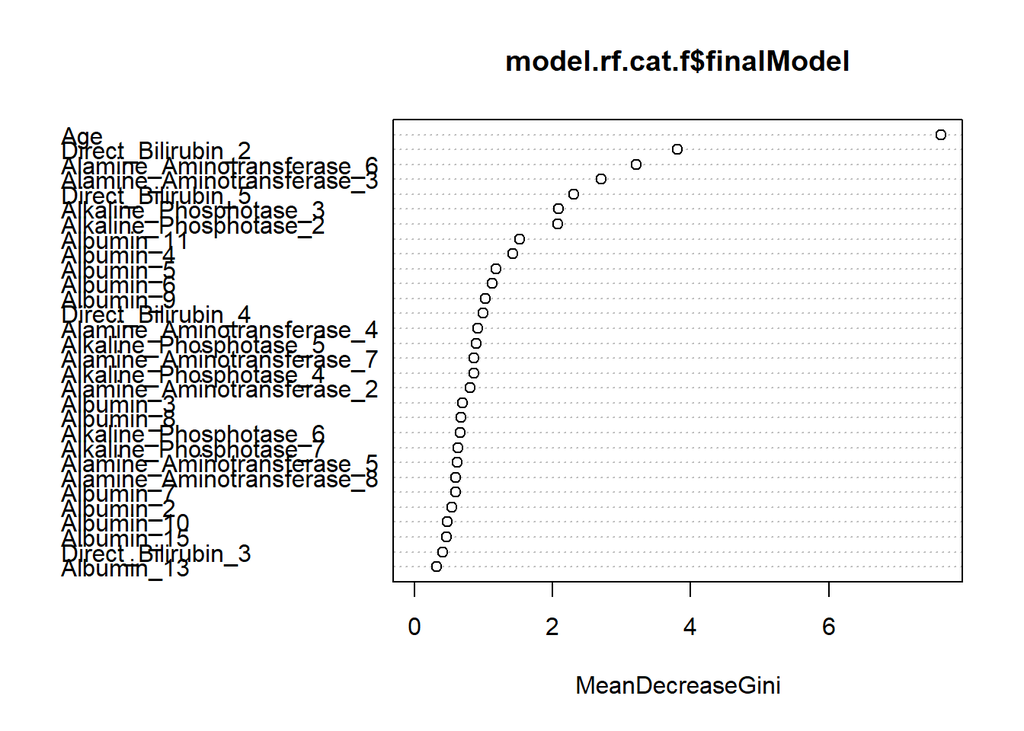

```r
# Plot MeanDecreaseGini
varImpPlot(model.rf.cat.f$finalModel, type = 2)
```

```r
# Prediction
predicted.classes <- model.rf.cat.f %>% predict(df.Test)
matrix.rf.cat.f <- confusionMatrix(predicted.classes, df.Test$Dataset)
matrix.rf.cat.f
```

```
## Confusion Matrix and Statistics
##
##                   Reference
## Prediction         no_liver_disease liver_disease
##   no_liver_disease                1             0
##   liver_disease                  32            82
##
##                Accuracy : 0.7217
##                  95% CI : (0.6305, 0.8013)
##     No Information Rate : 0.713
##     P-Value [Acc > NIR] : 0.4648
##
##                   Kappa : 0.0427
##
##  Mcnemar's Test P-Value : 4.251e-08
##
##             Sensitivity : 0.030303
##             Specificity : 1.000000
##          Pos Pred Value : 1.000000
##          Neg Pred Value : 0.719298
##              Prevalence : 0.286957
##          Detection Rate : 0.008696
##    Detection Prevalence : 0.008696
##       Balanced Accuracy : 0.515152
##
##        'Positive' Class : no_liver_disease
##
```

This model performed better with the ORIGINAL DATAFRAME - The overall accuracy was 73.91%.

### Summary

```r
x <- data.frame("MLA" = c("Log. Regression", "Log. Regression", "Log. Regression", "KNN", "KNN", "KNN", "CART", "CART", "CART", "Random Forest", "Random Forest", "Random Forest"),
                "Dataframe" = c("ORIGINAL", "ORIGINAL VALUES FITTED", "ORIGINAL CATEGORIZATED", "ORIGINAL", "ORIGINAL VALUES FITTED", "ORIGINAL CATEGORIZATED", "ORIGINAL", "ORIGINAL VALUES FITTED", "ORIGINAL CATEGORIZATED", "ORIGINAL", "ORIGINAL VALUES FITTED", "ORIGINAL CATEGORIZATED"),
                "Accuracy" = c(0.7565, 0.7391, 0.7739, 0.713, 0.6522, 0.6957, 0.687, 0.6435, 0.6435, 0.7391, 0.7304, 0.7217),
                "Number of Predictors" = c("6 of 11", "6 of 11", "7 of 11", "6 of 11", "5 of 11", "6 of 11", "4 of 11", "4 of 11", "4 of 11", "8 of 11", "7 of 11", "5 of 11"))
x
```

[output not shown]

[output cut: 2 more lines]

Considering this dataset with few observations and some extreme values, the Logistic Regression model performed better: accuracy value of 77.39% with 7 of 11 predictors.

In general, the models performed with a range accuracy of 64.35% - 77.39% and a number of predictors between 4 and 8.

The data transformation (dealing with extreme values and categorizing data) improved reasonably the performance of some prediction models.